# Table of Contents

## **1. Pythonの基本的な使い方**

### **1.1 変数**

```python
#　変数を定義する（代入）
a = "Hello, world!"
b = 100
c = 0.1
d = "Reiwa 3"
e = "令和3年"
```

#### **定義（代入）した変数の中身を表示する**

```python
print(a)
```

```
Hello, world!
```

printは文字を表示する関数 \ print(変数) \ print(100) \ print(0.1) \ print("Hello, world!") \ ()の中は変数以外に数字や文字列を入力することができる

**複数の変数を一緒に表示する**  
print()のカッコの中身をカンマで区切って書く  
print(変数, 変数, 変数,...)とする

```python
print(a, b, c)
```

```
Hello, world! 100 0.1
```

#### **変数の定義するとは**

変数に値（数値、文字列、数式など）を代入すると、変数が定義される  
代入するときは **a = b** のように **イコール(=)** を使う

変数名 = 値

これを変数を定義するという

#### **変数名**

変数名は基本的に自由に付けられる  
変数名に使える文字列は次の通り  
・ 数字（0-9）  
・ アルファベット（大文字、小文字）  
・ アンダースコア（_）  
・ 漢字  
など  
これらを組み合わせて変数名をつけることができる 変数名を付けるとき、大文字小文字は区別される 数字を文頭（1文字目）に使えない

#### **アルファベットを使って変数を定義する**

「Tokyo」という文字列を「Capital」という変数に定義する

```python
Capital = "Tokyo"
print(Capital)
```

```
Tokyo
```

#### **使える文字列を組み合わせて変数を定義する**

「Tokyo」という文字列を「Olympic_2020」という変数に定義する

```python
Olympic_2020 = "Tokyo"
print(Olympic_2020)
```

```
Tokyo
```

「Tokyo」という文字列を「東京2020」という変数に定義する

```python
東京2020 = "Tokyo"
print(東京2020)
```

```
Tokyo
```

上で述べた通り、数字は文頭に使えない

```python
2020Tokyo = "Tokyo"
```

```
  File "/var/folders/8h/ssrf_h6x5j9fq6ns_h2xfb5h0000gp/T/ipykernel_65076/1992670644.py", line 1
    2020Tokyo = "Tokyo"
            ^
SyntaxError: invalid syntax
```

SyntaxErrorが表示される  
SyntaxErrorは構文エラーと言い、Pythonのコードの文法が正しくないときに発生する  
書き方が間違っている箇所がある場合このエラーが表示される（変数名の文頭が数字になっている）  
invalid syntaxは「構文に間違いがある」ことを示している

### **1.2 Pythonのデータ型**

数値型（整数、浮動小数点）、文字型、リスト型、辞書型、bool型がある  
また、変数のデータ型を調べる時はtype()を使う

type(変数)

整数: int型  
浮動小数点: float型  
文字型: str型  
リスト型: list型  
辞書型: dict型  
bool型: bool型

#### **整数**

「a」という変数に整数「1000」を代入すると変数「a」のデータ型はint（整数）型となる

```python
a = 1000
```

```python
a
```

```
1000
```

```python
type(a)
```

```
int
```

#### **浮動小数点数**

「b」という変数に浮動小数点「3.14159265359」を代入すると変数「b」のデータ型はfloat（浮動小数点数）型となる

```python
b = 3.14159265359
```

```python
b
```

```
3.14159265359
```

```python
type(b)
```

```
float
```

#### **文字型**

「c」という変数に文字列「Hello, world!」を代入すると変数「c」のデータ型はstr（文字列）型となる

```python
c = "Hello, world!"
```

```python
c
```

```
'Hello, world!'
```

```python
type(c)
```

```
str
```

#### **リスト（配列）型**

「l」という変数に「1000, 3.14159265359, "Hello, world!", 2021, "Reiwa 3", "令和3年"」を代入すると変数「l」のデータ型はlist型となる

変数 = [要素, 要素, ...]

変数[リスト番号] リスト番号:0, 1, 2, ...

```python
l = [1000, 3.14159265359, "Hello, world!", 2021, "Reiwa 3", "令和3年"]
```

```python
l
```

```
[1000, 3.14159265359, 'Hello, world!', 2021, 'Reiwa 3', '令和3年']
```

```python
type(l)
```

```
list
```

```python
l[0]
```

```
1000
```

```python
l[2]
```

```
'Hello, world!'
```

**空のリストを定義する**  
計算した系列データや抽出したデータなどを格納するときに使う  
いわゆる物を入れる空箱を作成する

```python
l = []
```

```python
print(l)
```

```
[]
```

```python
type(l)
```

```
list
```

#### **辞書型（dictionary型）**

キーと値という２つのペアで保持するデータ型を言う  
定義は次のようにする

辞書名 = {"キー" : "値", ・・・}

```python
i_am = {"名前": "Yamada", "E-mail": "yamada@toyaku.com" }
print(i_am["名前"])
print(i_am["E-mail"])
```

```
Yamada
yamada@toyaku.com
```

辞書型とリスト型と組み合わせることで表形式にできる（padasデータフレーム）

#### **boolean型（bool型）**

ブール型はプログラミング言語で使われる真偽値（True or False）のことであり、if文などの条件を分岐するときに使用する

#### **bool型の定義する**

数値型や文字列型と同様に定義できる

```python
bool_true = True
bool_false = False

print(bool_true)
print(bool_false)
```

```
True
False
```

### **1.3 基本的な計算**

Pythonでは足し算、引き算、掛け算、べき乗、割り算、切り捨ての割り算、剰余など基本的な数値計算を行うことができる  
またこれらの計算を行うときは **+** や **-** などの **演算子** を使う

**Pythonで使える演算子**  
加算（足し算）：+  
減算（引き算）：-  
乗算（掛け算）：*  
除算（割り算）：/  
剰余（割り算の余り）：%  
べき乗：**  
切り捨て除算：//

これらの演算子を用いて実際に計算してみよう

**足し算**

```python
5 + 2
```

```
7
```

**引き算**

```python
11 - 7
```

```
4
```

**掛け算**

```python
12 * 7
```

```
84
```

**べき乗**

```python
12 ** 7
```

```
35831808
```

**()が入った計算**

```python
(14 - 5)**5
```

```
59049
```

**割り算**

```python
97 / 5
```

```
19.4
```

**切り捨ての割り算**

```python
97 // 5
```

```
19
```

**剰余**

```python
97 % 5
```

```
2
```

**小数点の計算**

```python
0.2 + 0.3
```

```
0.5
```

**小数点の計算**

```python
1.4 * 1.2
```

```
1.68
```

#### **変数を使った計算1（BMIを計算する）**

上記で学んだ変数を使った計算も行える  
ここではBMIの計算式を例題にする

BMIの計算式 $$ BMI = 体重(kg) \div 身長(m)^2 $$

```python
# 体重をweight変数に代入する
weight = 64.4

# 身長をweight変数に代入する
height = 171.7 / 100

# BMIを計算する
weight / height ** 2
```

```
21.84465937086703
```

#### **変数を使った計算2（Duboisの式 体表面積（BSA）を計算する）**

体表面積（BSA）を計算するDuboisの式を変数を使って計算してみよう

Duboisの式 $$ BSA(m^2) = 身長(cm)^{0.725} \times 体重(kg)^{0.425} \times 0.007184 $$

weightとheight変数に自分の体重と身長の値を書いて計算してみよう

```python
# 体重をweight変数に代入する
# weight = 55
weight =

# 身長をweight変数に代入する
# height = 163
height =

# BSAを計算する
(height**0.725) * (weight**0.425) * 0.007184
```

### **1.4 条件文（分岐）**

条件文はある条件次第プログラムを実行するかしないか、別のプログラムに切り替えるために使用する

#### **if文**

BMIの値によって「痩せています」、「太り気味です」、「標準体重です」を表示させる条件文を書いてみよう

```python
BMI = 22

if BMI < 18.5:
    print("痩せています")

elif BMI >= 25:
    print("太り気味です")

else:
    print("標準体重です")
```

```
標準体重です
```

### **1.5 繰り返し文（反復）**

繰り返し文（反復）はPythonなどのプログラミング言語を利用する最大のメリットの１つ

#### **for文**

for文を使うことで1から50までの数字を順番に表示したり、リスト（配列）の要素を順番に取り出せる

```python
【for文の書き方】
for 変数 in オブジェクト:
    実行するプログラム
```

Pythonでのfor文はこのように書く  
オブジェクトにはリスト（配列）などを書く  
書く時にオブジェクトの右側にコロン（：）を書くことに注意する

**配列を用意する**

```python
l = [1000, 3.14159265359, "Hello, world!", 2021, "Reiwa 3", "令和3年"]
```

**for文を実行する**  
変数に「i」、オブジェクトに「l」として、実行するプログラムは「print(i)」とする

```python
for i in l:
    print(i)
```

```
1000
3.14159265359
Hello, world!
2021
Reiwa 3
令和3年
```

**数字を順番に表示する**  
数字を順番に表示するときはrange()を使うと便利である

【rangeの使い方】  
range(開始番号, 終了番号)

ここで終了番号は表示されないことに注意する  
range(0, 5)としたら、0,1,2,3,4と出力される

範囲を指定せずrange(5)とだけ書いた場合は開始番号は自動的に「0」となる

**range()を使ってfor文を実行する**  
変数に「i」、オブジェクトに「range(0, 5)」として、実行するプログラムは「print(i)」とする

```python
for i in range(0, 5):
    print(i)
```

```
0
1
2
3
4
```

#### **while文**

while文をfor文と同様に繰り返し処理するための構文である

```python
【while文の書き方】
while 条件文:
    実行するプログラム
```

while文はfor文と違い、条件を満たすまで繰り返し処理を行う  
書く時に条件文の右側にコロン（：）を書くことに注意する  
例として数字を0から4まで表示するwhile文を書く

```python
i = 0
while i < 5:
    print(i)
    i = i + 1
```

```
0
1
2
3
4
```

変数「i」に「0」を代入し、変数「i」が5よりも小さい間、変数「i」を表示する

「i = i + 1」という表現は次のとおりである

while文の1回目  
i = 0 + 1  
↓  
i = 1  
変数iに 1 が入る

while文の2回目  
i = 1 + 1  
↓  
i = 2  
変数iに 2 が入る

while文の3回目  
i = 2 + 1  
↓  
i = 3  
変数iに 3 が入る

のように1づつにiの値が増えていく

#### **break文とcontinue文**

break文とcontinue文はfor文やwhile文などの反復処理をする際、処理を途中で止める、ある条件の時のみ処理を止める時に使う

**break文を使ってみる**  
数字を0から4表示するプログラムを例にする  
変数iが2になったら処理を止めるプログラムを書く

数字を0から4表示するプログラムの途中に次の条件文を書く if i == 2: break

```python
for i in range(0, 5):
    if i == 2:
        break
    print(i)
```

```
0
1
```

rangeは0から5と指定しているが、1までしか表示されなかったことがわかる  
while文でも同様に書いてみる

```python
i = 0
while i < 5:
    if i == 2:
        break
    print(i)
    i = i + 1
```

```
0
1
```

**continue文を使ってみる**  
continue文はある条件の時のみ処理を止める、条件を満たす時処理をスキップさせることができる

数字を0から4表示するプログラムの途中に次の条件文を書く if i == 2: continue

```python
for i in range(0, 5):
    if i == 2:
        continue
    print(i)
```

```
0
1
3
4
```

数字の2が表示されない  
変数iが2の時、処理がスキップされたことがわかる  
while文でも書いてみよう  
ただし、条件文とcontineの間に「i = i + 1」を書く必要がある  
これを書かないと、無限ループしてしまう！

```python
i = 0
while i < 5:
    if i == 2:
        i = i + 1
        continue
    print(i)
    i = i + 1
```

```
0
1
3
4
```

### **1.6 ライブラリ（モジュール）の利用**

#### **math**

```python
#math モジュールを読み込む
import math
```

```python
#平方根
#sqrt(x)
num = math.sqrt(5)
print(num)
```

```
2.23606797749979
```

```python
#x以下の最大の整数を返す。
#floor(x)
math.floor(3.3)
```

```
3
```

```python
#x以上の最小の整数を返す。
#ceil(x)
math.ceil(3.3)
```

```
4
```

```python
#小数点以下を切り捨てる。
#trunc(x)
math.trunc(3.3)
```

```
3
```

```python
#eのx乗を返す。
#exp(x)
math.exp(3)
```

```
20.085536923187668
```

```python
#xの自然対数を返す。
#log(x)
math.log(3)
```

```
1.0986122886681098
```

```python
#xのy乗を返す。
#pow(x,y)
math.pow(3,2)
```

```
9.0
```

```python
#sin()
math.sin(3)
```

```
0.1411200080598672
```

```python
#cos()
math.cos(3)
```

```
-0.9899924966004454
```

```python
#tan()
math.tan(3)
```

```
-0.1425465430742778
```

#### **ライブラリの読み込み方**

ライブラリを読み込むとき、基本的には下記のように読み込む

import math

ただし、変数が定義できるようにライブラリを読み込むときも、定義して読み込むことができる  
定義して読み込むときは「import XXX as YYY」という形で読み込む

import math as m

```python
import math # そのまま読み込む
import math as m # mとして読み込む
```

mathとして実行する

```python
math.sqrt(100)
```

```
10.0
```

mとして実行する

```python
m.sqrt(100)
```

```
10.0
```

#### **numpy**

多次元配列の計算に役立つ

```python
import numpy as np
a = np.arange(12) # １次元配列を生成する
b = np.reshape(a, (3, 4)) # aを3×4（3行、4列）の２次元配列に変形する
```

```python
print(a)
```

```
[ 0  1  2  3  4  5  6  7  8  9 10 11]
```

```python
print(a[5])
```

```
5
```

```python
print(b)
```

```
[[ 0  1  2  3]
 [ 4  5  6  7]
 [ 8  9 10 11]]
```

```python
print(b[2])
```

```
[ 8  9 10 11]
```

```python
c = np.random.randn(2,3) # 2×3の乱数行列
```

```python
print(c)
```

```
[[-0.90297341 -0.22612973 -0.07104862]
 [-0.13523893 -1.13261102  0.60519629]]
```

```python
print(c + c) # 足し算
```

```
[[-1.80594683 -0.45225947 -0.14209724]
 [-0.27047786 -2.26522204  1.21039257]]
```

```python
print(c - c) # 引き算
```

```
[[0. 0. 0.]
 [0. 0. 0.]]
```

```python
print(c * 100) # 掛け算
```

```
[[ -90.29734136  -22.6129733    -7.10486178]
 [ -13.52389323 -113.26110182   60.51962861]]
```

### **1.7 数値計算とグラフ化**

#### **SIR 数理モデル（感染症数理モデル）**

$$ \frac{\mathrm{d}S}{\mathrm{d}t}(t) = -\beta S(t)I(t) $$

$$ \frac{\mathrm{d}I}{\mathrm{d}t}(t) = \beta S(t)I(t) - \gamma I(t) $$

$$ \frac{\mathrm{d}R}{\mathrm{d}t}(t) = \gamma I(t) $$

総人口 = 未感染者数 + 感染者数 + 回復者（免疫保持者）の数  
S(t) = 時間 t における未感染者数  
I(t) = 時間 t における感染者数  
R(t) = 時間 t における回復者（免疫保持者）数

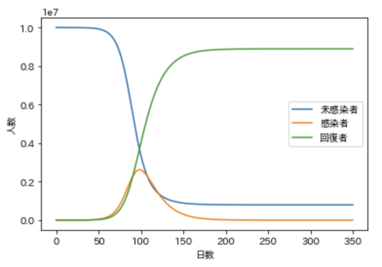

```python
from IPython.display import Image

Image("SIR.png")
```

#### **計算手順**

第0ステップ  
初期値の設定  
総人口 N : 1000万人  
初期感染者 I(0)=100人  
初期未感染者数 S(0)=10000000-100  
初期回復者 R(0)=0

感染率 β=m×p/N  
m: 1日１人あたり平均接触人数  
（ここではm=10人に設定）  
p: 接触毎に感染が生じる1日あたりの確率  
（ここではp=0.02に設定）  
感染率β=10×0.02/N  
回復率 γ=1/回復日数  
（ここでは感染者の回復日数を14日に設定)  
回復率γ=1/14=0.071…

第1ステップ  
dS(ある時間の未感染者数の変化量) = -(感染率) *(初期未感染者数)* (初期感染者数)  
dI(ある時間の感染者数の変化量) = (感染率) *(初期未感染者数)* (初期感染者数) - (回復率) (初期感染者数)  
dR(ある時間の回復者数の変化量) = (回復率) (初期感染者数)

S（ある時間後の未感染者数） = S0（初期未感染者数） + dS(ある時間の未感染者数の変化量)  
I（ある時間後の感染者数） = I0（初期感染者数） + dI（ある時間の感染者数の変化量）  
R（ある時間後の回復者） = R0（初期回復者数） + dR(ある時間の回復者数の変化量)

第2ステップ-第N回（日数）ステップ

dS(ある時間の未感染者数の変化量) = -(感染率) *(現在の未感染者数)* (現在の感染者数)  
dI(ある時間の感染者数の変化量) = (感染率) *(現在の未感染者数)* (現在の感染者数) - (回復率) (現在の感染者数)  
dR(ある時間の回復者数の変化量) = (回復率) (現在の感染者数)

S（ある時間後の未感染者数） = tempS（現在の未感染者数） + dS(ある時間の未感染者数の変化量)  
I（ある時間後の感染者数） = tempI（現在の感染者数） + dI（ある時間の感染者数の変化量）  
R（ある時間後の回復者） = tempR（現在の回復者数） + dR(ある時間の回復者数の変化量)

第2ステップ-第N回（日数）ステップを繰り返し計算することで感染者数の日時変化をシミュレーションできる．

```python
import numpy as np

#第0ステップ
N = 1000 * 10**4  #総人口 N
I0 = 100  #初期感染者
S0 = N - I0  #初期未感染者数
R0 = 0  #初期回復者

beta = 10 * (0.02/N)  #感染率
gamma = 1/14  #回復率


#第1ステップ
#dS/dt =　-beta*S*I
#dI/dt = beta*S*I-gamma*I
#dR/dt = gamma*I

dS = -(beta) * S0 * I0  #ある時間の未感染者数の変化量
dI = (beta) * S0 * I0 - (gamma) * I0  #ある時間の感染者数の変化量
dR = (gamma) * I0  #ある時間の回復者数の変化量


#第2ステップ

#現在の未感染者，感染者，回復者の値を一時的に格納（代入）する．
tempS = S0 + dS  #現在の未感染者数
tempI = I0 + dI  #現在の感染者数
tempR = R0 + dR  #現在の回復者数


#現在の未感染者，感染者，回復者の値を時系列として保存するために，リストを作成する．
S = list()
I = list()
R = list()

#現在の未感染者，感染者，回復者の値をリストに格納する．
S = np.append(S, tempS)
I = np.append(I, tempI)
R = np.append(R, tempR)

#未感染者，感染者，回復者の値を350回（350日）繰り返し計算する．
for i in range(350):

    dS = - (beta) * tempS * tempI  #ある時間の未感染者数の変化量
    tempS = tempS + dS  #現在の未感染者数
    S = np.append(S, tempS)  #現在の未感染者数を格納

    dI = (beta) * tempS * tempI - (gamma) * tempI  #ある時間の感染者数の変化量
    tempI = tempI + dI  #現在の感染者数
    I = np.append(I, tempI)  #現在の感染者数を格納

    dR = (gamma) * tempI  #ある時間の回復者数の変化量
    tempR = tempR + dR  #現在の回復者数
    R = np.append(R, tempR)  #現在の回復者数を格納
```

#### **グラフのプロット**

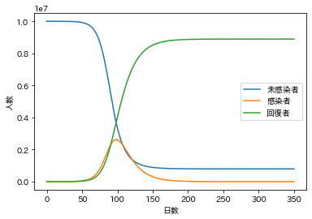

```python
import matplotlib.pyplot as plt
import japanize_matplotlib

#横軸の日数配列を作成する．
D = np.array(range(351))

#横軸の日数，縦軸を未感染者，感染者，回復者として図示する．
plt.plot(D, S, label="未感染者")
plt.plot(D, I, label="感染者")
plt.plot(D, R, label="回復者")

#縦軸と横軸にラベルをつける．
plt.xlabel('日数')
plt.ylabel('人数')

# 凡例の表示
plt.legend()

# プロット表示(設定の反映)
plt.show()
```

## **2. データ処理**

### **2.1 pandas**

```python
import pandas as pd #Pandasをpdという名前で扱えるようにする
```

#### **Series**

1列のみのデータ型です。

```python
s = pd.Series([1,2,3,5,7,11])
print(s)
```

```
0     1
1     2
2     3
3     5
4     7
5    11
dtype: int64
```

```python
print(s[4])
```

```
7
```

#### **データフレーム**

データフレームは2次元のデータ構造で、Pandasでは最も多く使われるデータ型である  
辞書型のデータ形式を定義し、pandas.DataFrame（ここではpd.DataFrame）を用いてデータフレーム化することができる

```python
data = {
    '名前' : ['田中', '佐藤', '山田'],
    '役職' : ['営業部部長', '広報部課長', '技術顧問'],
    '身長' : [193, 163, 173]
    }
df = pd.DataFrame(data)
print(df)
```

```
   名前     役職   身長
0  田中  営業部部長  193
1  佐藤  広報部課長  163
2  山田   技術顧問  173
```

辞書型を定義せず直接、pd.DataFrameに代入しても良い

```python
df = pd.DataFrame({
    '名前' : ['田中', '佐藤', '山田'],
    '役職' : ['営業部部長', '広報部課長', '技術顧問'],
    '身長' : [193, 163, 173]
    })
print(df)
```

```
   名前     役職   身長
0  田中  営業部部長  193
1  佐藤  広報部課長  163
2  山田   技術顧問  173
```

#### **列名を変更・置換する**

.colunmsを使って列名を変更・置換できる

```python
df.columns = ["Name", "Position", "height"]
print(df)
```

```
  Name Position  height
0   田中    営業部部長     193
1   佐藤    広報部課長     163
2   山田     技術顧問     173
```

#### **データフレームを表形式で表示する**

データフレームを表形式で表示するにはdisplay関数を使う

```python
display(df)
```

|  | Name | Position | height |
| --- | --- | --- | --- |
| 0 | 田中 | 営業部部長 | 193 |
| 1 | 佐藤 | 広報部課長 | 163 |
| 2 | 山田 | 技術顧問 | 173 |

#### **head(), tail()**

Pandasのデータの中身を見る際に.head()を使うと先頭から5つのデータを表示する  
また引数に数字を入力することで、その数字分先頭からデータを表示する  
また、tail()を使うと末尾から5つのデータを表示する

```python
import numpy as np

df = pd.DataFrame(np.random.randn(20,2))
#np.random.randn():平均0、標準偏差1の正規分布の乱数を生成する関数

print(df)
```

```
           0         1
0   1.358992 -1.033572
1  -0.909457 -0.094579
2  -0.035313  0.456775
3   0.235573  1.122068
4  -0.301630  0.113386
5   1.116457 -0.117458
6   0.110365 -0.309181
7  -1.110676 -0.374141
8  -1.149042 -0.607316
9  -0.293199 -0.332377
10 -0.204947 -1.060874
11  0.121531  2.116323
12  1.238861  0.272872
13 -0.105376  0.680370
14 -0.875957  0.166593
15 -0.974086 -0.675887
16 -0.137729 -0.542511
17  0.481422 -0.198029
18 -0.584224 -1.186997
19 -1.726517  0.231981
```

**head()を使って先頭から5行のデータを表示する**

```python
print(df.head()) # 先頭から5つのデータ
```

```
          0         1
0  1.358992 -1.033572
1 -0.909457 -0.094579
2 -0.035313  0.456775
3  0.235573  1.122068
4 -0.301630  0.113386
```

**tail()を使って末尾から5行のデータを表示する**

```python
print(df.tail()) # 末尾から5つのデータ
```

```
           0         1
15 -0.974086 -0.675887
16 -0.137729 -0.542511
17  0.481422 -0.198029
18 -0.584224 -1.186997
19 -1.726517  0.231981
```

#### **データの抽出：loc,iloc**

locとilocはデータを抽出するために使う

```python
df = pd.DataFrame([[10, 20], [25, 50]], index=["1行", "2行"], columns=["1列", "2列"])
```

locは行名もしくは列名を指定することで特定の値を抽出できる

```python
print(df.loc["1行", :])
```

```
1列    10
2列    20
Name: 1行, dtype: int64
```

```python
print(df.loc[: , ["1列", "2列"]])
```

```
    1列  2列
1行  10  20
2行  25  50
```

ilocはindexを指定することで特定の値を抽出できる

```python
print(df.iloc[1:2])# index指定が可能
```

```
    1列  2列
2行  25  50
```

```python
print(df.iloc[:, -1])  # 負のインデックスを使い、末尾の要素から位置指定し2列目の全ての行を抽出できる
```

```
1行    20
2行    50
Name: 2列, dtype: int64
```

locとilocは共に行と列を指定して抽出する  
loc : 行と列をラベルで指定して抽出する  
iloc : 行と列を番号で指定して抽出する

#### **loc**

```python
df = pd.DataFrame({
    '名前' :['田中', '佐藤', '山田', '山崎', '織田', '徳川', '豊臣', '長宗我部', '毛利'],
    '役職' : ['営業部部長', '広報部課長', '技術顧問', '人事部部長', '人事部課長', '総務部部長', '情報システム部部長', '情報システム部係長', '代表取締役'],
    '身長' : [193, 163, 173, 155, 165, 188, 174, 172, 171],
    '体重' : [70, 59, 68, 60, 62, 75, 61, 75, 69],
    '血液型' : ['A', 'O', 'AB', 'B', 'A', 'B', 'O', 'A', 'AB'],
    '星座' : ['山羊座', '牡羊座', '乙女座', '獅子座', '山羊座', '双子座', 'さそり座', 'てんびん座', '乙女座']
    })
```

```python
print(df)
```

```
     名前         役職   身長  体重 血液型     星座
0    田中      営業部部長  193  70   A    山羊座
1    佐藤      広報部課長  163  59   O    牡羊座
2    山田       技術顧問  173  68  AB    乙女座
3    山崎      人事部部長  155  60   B    獅子座
4    織田      人事部課長  165  62   A    山羊座
5    徳川      総務部部長  188  75   B    双子座
6    豊臣  情報システム部部長  174  61   O   さそり座
7  長宗我部  情報システム部係長  172  75   A  てんびん座
8    毛利      代表取締役  171  69  AB    乙女座
```

```python
print(df.loc[3,'役職'])  #行（インデックス）が'3'で列（カラム）が'役職'の要素
```

```
人事部部長
```

```python
print(df.loc[3, ]) # インデックスが3の要素
```

```
名前        山崎
役職     人事部部長
身長       155
体重        60
血液型        B
星座       獅子座
Name: 3, dtype: object
```

```python
print(df.loc[:,'役職']) #カラムが'役職'の要素
```

```
0        営業部部長
1        広報部課長
2         技術顧問
3        人事部部長
4        人事部課長
5        総務部部長
6    情報システム部部長
7    情報システム部係長
8        代表取締役
Name: 役職, dtype: object
```

```python
print(df.loc[0:4, '身長':'星座']) # インデックスを0から4まで，カラムを'身長'から'星座'までの要素
```

```
    身長  体重 血液型   星座
0  193  70   A  山羊座
1  163  59   O  牡羊座
2  173  68  AB  乙女座
3  155  60   B  獅子座
4  165  62   A  山羊座
```

#### **iloc**

```python
df.iloc[0,1] #インデックスが0，列が1（'役職'）
```

```
'営業部部長'
```

```python
df.iloc[1:4, 0] #インデックスが1から4，列が0（'名前'）
```

```
1    佐藤
2    山田
3    山崎
Name: 名前, dtype: object
```

#### **特定の列をインデックスにする**

```python
df = pd.DataFrame({
    '名前' :['田中', '佐藤', '山田','山崎', '織田', '徳川', '豊臣', '長宗我部', '毛利'],
    '役職' : ['営業部部長', '広報部課長', '技術顧問', '人事部部長', '人事部課長', '総務部部長', '情報システム部部長', '情報システム部係長', '代表取締役'],
    '身長' : [193, 163, 173, 155, 165, 188, 174, 172, 171],
    '体重' : [70, 59, 68, 60, 62, 75, 61, 75, 69],
    '血液型' : ['A', 'O', 'AB', 'B', 'A', 'B', 'O', 'A', 'AB'],
    '星座' : ['山羊座', '牡羊座', '乙女座', '獅子座', '山羊座', '双子座', 'さそり座', 'てんびん座', '乙女座']
    })
print(df)
```

```
     名前         役職   身長  体重 血液型     星座
0    田中      営業部部長  193  70   A    山羊座
1    佐藤      広報部課長  163  59   O    牡羊座
2    山田       技術顧問  173  68  AB    乙女座
3    山崎      人事部部長  155  60   B    獅子座
4    織田      人事部課長  165  62   A    山羊座
5    徳川      総務部部長  188  75   B    双子座
6    豊臣  情報システム部部長  174  61   O   さそり座
7  長宗我部  情報システム部係長  172  75   A  てんびん座
8    毛利      代表取締役  171  69  AB    乙女座
```

#### **set_index('',inplace=True)**

```python
df.set_index('名前',inplace=True)
print(df)
```

```
             役職   身長  体重 血液型     星座
名前
田中        営業部部長  193  70   A    山羊座
佐藤        広報部課長  163  59   O    牡羊座
山田         技術顧問  173  68  AB    乙女座
山崎        人事部部長  155  60   B    獅子座
織田        人事部課長  165  62   A    山羊座
徳川        総務部部長  188  75   B    双子座
豊臣    情報システム部部長  174  61   O   さそり座
長宗我部  情報システム部係長  172  75   A  てんびん座
毛利        代表取締役  171  69  AB    乙女座
```

```python
print(df.loc['田中', ])
```

```
役職     営業部部長
身長       193
体重        70
血液型        A
星座       山羊座
Name: 田中, dtype: object
```

#### **条件による行の抽出(query)**

queryを利用することでpandas.DataFrameの列の値に対し、条件に応じて行を抽出することが可能です。

```python
df = pd.DataFrame([[10, 20,30, 30], [25, 50,65, 80]], index=["1行", "2行"], columns=["A", "B", "C", "D"])
print(df)
```

```
     A   B   C   D
1行  10  20  30  30
2行  25  50  65  80
```

```python
print(df.query('A < 25 and C == 30'))
```

```
     A   B   C   D
1行  10  20  30  30
```

#### **Pandas ソート**

インデックス (データフレームの行ラベル・列ラベル)を使う方法（sort_index）と指定した列名の値に基づいてソートする方法（sort_values）がある  
「.sort_index()」と「.sort_values()」はそのまま使うと、昇順（小さい順）でのソートする  
引数にascending=Falseを入力すると降順(大きい順)のソートする

```python
df = pd.DataFrame({
    '名前' :['田中', '佐藤', '山田', '山崎', '織田', '徳川', '豊臣', '長宗我部', '毛利'],
    '役職' : ['営業部部長', '広報部課長', '技術顧問', '人事部部長', '人事部課長', '総務部部長', '情報システム部部長', '情報システム部係長', '代表取締役'],
    '身長' : [193, 163, 173, 155, 165, 188, 174, 172, 171],
    '体重' : [70, 59, 68, 60, 62, 75, 61, 75, 69],
    '血液型' : ['A', 'O', 'AB', 'B', 'A', 'B', 'O', 'A', 'AB'],
    '星座' : ['山羊座', '牡羊座', '乙女座', '獅子座', '山羊座', '双子座', 'さそり座', 'てんびん座', '乙女座']
    })

###行ラベルでソートする###
print('*********************ソート前*********************')
display(df) #ソートする前
print('*********************ソート後*********************')
df.sort_index(ascending=False) #ソートした後
```

```
*********************ソート前*********************
```

|  | 名前 | 役職 | 身長 | 体重 | 血液型 | 星座 |
| --- | --- | --- | --- | --- | --- | --- |
| 0 | 田中 | 営業部部長 | 193 | 70 | A | 山羊座 |
| 1 | 佐藤 | 広報部課長 | 163 | 59 | O | 牡羊座 |
| 2 | 山田 | 技術顧問 | 173 | 68 | AB | 乙女座 |
| 3 | 山崎 | 人事部部長 | 155 | 60 | B | 獅子座 |
| 4 | 織田 | 人事部課長 | 165 | 62 | A | 山羊座 |
| 5 | 徳川 | 総務部部長 | 188 | 75 | B | 双子座 |
| 6 | 豊臣 | 情報システム部部長 | 174 | 61 | O | さそり座 |
| 7 | 長宗我部 | 情報システム部係長 | 172 | 75 | A | てんびん座 |
| 8 | 毛利 | 代表取締役 | 171 | 69 | AB | 乙女座 |

```
*********************ソート後*********************
```

|  | 名前 | 役職 | 身長 | 体重 | 血液型 | 星座 |
| --- | --- | --- | --- | --- | --- | --- |
| 8 | 毛利 | 代表取締役 | 171 | 69 | AB | 乙女座 |
| 7 | 長宗我部 | 情報システム部係長 | 172 | 75 | A | てんびん座 |
| 6 | 豊臣 | 情報システム部部長 | 174 | 61 | O | さそり座 |
| 5 | 徳川 | 総務部部長 | 188 | 75 | B | 双子座 |
| 4 | 織田 | 人事部課長 | 165 | 62 | A | 山羊座 |
| 3 | 山崎 | 人事部部長 | 155 | 60 | B | 獅子座 |
| 2 | 山田 | 技術顧問 | 173 | 68 | AB | 乙女座 |
| 1 | 佐藤 | 広報部課長 | 163 | 59 | O | 牡羊座 |
| 0 | 田中 | 営業部部長 | 193 | 70 | A | 山羊座 |

```python
###列ラベルでソートする###
print('*********************ソート前*********************')
display(df) #ソートする前
print('*********************ソート後*********************')
df.sort_values('身長', ascending=False) #ソートした後
```

```
*********************ソート前*********************
```

|  | 名前 | 役職 | 身長 | 体重 | 血液型 | 星座 |
| --- | --- | --- | --- | --- | --- | --- |
| 0 | 田中 | 営業部部長 | 193 | 70 | A | 山羊座 |
| 1 | 佐藤 | 広報部課長 | 163 | 59 | O | 牡羊座 |
| 2 | 山田 | 技術顧問 | 173 | 68 | AB | 乙女座 |
| 3 | 山崎 | 人事部部長 | 155 | 60 | B | 獅子座 |
| 4 | 織田 | 人事部課長 | 165 | 62 | A | 山羊座 |
| 5 | 徳川 | 総務部部長 | 188 | 75 | B | 双子座 |
| 6 | 豊臣 | 情報システム部部長 | 174 | 61 | O | さそり座 |
| 7 | 長宗我部 | 情報システム部係長 | 172 | 75 | A | てんびん座 |
| 8 | 毛利 | 代表取締役 | 171 | 69 | AB | 乙女座 |

```
*********************ソート後*********************
```

|  | 名前 | 役職 | 身長 | 体重 | 血液型 | 星座 |
| --- | --- | --- | --- | --- | --- | --- |
| 0 | 田中 | 営業部部長 | 193 | 70 | A | 山羊座 |
| 5 | 徳川 | 総務部部長 | 188 | 75 | B | 双子座 |
| 6 | 豊臣 | 情報システム部部長 | 174 | 61 | O | さそり座 |
| 2 | 山田 | 技術顧問 | 173 | 68 | AB | 乙女座 |
| 7 | 長宗我部 | 情報システム部係長 | 172 | 75 | A | てんびん座 |
| 8 | 毛利 | 代表取締役 | 171 | 69 | AB | 乙女座 |
| 4 | 織田 | 人事部課長 | 165 | 62 | A | 山羊座 |
| 1 | 佐藤 | 広報部課長 | 163 | 59 | O | 牡羊座 |
| 3 | 山崎 | 人事部部長 | 155 | 60 | B | 獅子座 |

### **2.2 データの入出力**

Pandasはデータをファイルから入力及び解析後のデータをファイルを出力する機能がある． Pandasでは大きく4つの入出力が可能．

1. テキスト形式のデータファイルからデータの読み込み
2. バイナリ形式のデータファイルからデータの読み込み
3. データベースからのデータの読み込み
4. Web上からのデータの読み込み

Pandasでcsvファイルを読み込む場合は，「read_csv」を使う．データの出力には「to_csv」や「to_excel」などが利用可能．csv以外にも，「read_json」や「read_excel」，「read_sql」や出力メソッドもある． TSVファイルの場合は，「read_table」を使うことで区切り文字がタブ\tのファイルを処理することができる．

#### **テキスト形式のデータファイルからデータの読み込み**

```python
import pandas as pd

#sample.csvを読み込んで、dataという変数に代入する
data = pd.read_csv('sample.csv')
print(data)
```

```
   Data1  Data2  Data3  Data4  Data5
0    4.0    2.0    3.2    4.0    5.5
1    NaN    6.0    NaN    7.0    NaN
2    8.0    NaN   12.0    5.1    9.9
3    1.0    2.0   11.0    2.1    4.9
4    3.0    NaN   15.1    7.1    3.9
5    5.0    2.0    0.1    6.1    1.4
6    9.0    2.0    3.5    7.1    8.4
```

#### **Web上からのデータの読み込み**

```python
import pandas as pd

#新型コロナ新規陽性者数の推移（日別） 厚生労働省のオープンデータ
data = pd.read_csv('https://covid19.mhlw.go.jp/public/opendata/newly_confirmed_cases_daily.csv')
print(data)
```

```
          Date    ALL  Hokkaido  Aomori  Iwate  Miyagi  Akita  Yamagata  \
0    2020/1/16      1         0       0      0       0      0         0
1    2020/1/17      0         0       0      0       0      0         0
2    2020/1/18      0         0       0      0       0      0         0
3    2020/1/19      0         0       0      0       0      0         0
4    2020/1/20      0         0       0      0       0      0         0
..         ...    ...       ...     ...    ...     ...    ...       ...
819  2022/4/14  55210      2768     430    432     598    357       257
820  2022/4/15  49711      2605     479    302     507    362       215
821  2022/4/16  47543      2457     418    357     567    296       192
822  2022/4/17  39214      2113     294    340     415    247       185
823  2022/4/18  24164      1766     153    188     219    182       130

     Fukushima  Ibaraki  ...  Ehime  Kochi  Fukuoka  Saga  Nagasaki  Kumamoto  \
0            0        0  ...      0      0        0     0         0         0
```

[output cut: 25 more lines]

#### **データの書き出し（CSV）**

```python
import pandas as pd
df = pd.DataFrame({
    '名前' :['田中', '佐藤', '山田','山崎', '織田', '徳川', '豊臣', '長宗我部', '毛利'],
    '役職' : ['営業部部長', '広報部課長', '技術顧問', '人事部部長', '人事部課長', '総務部部長', '情報システム部部長', '情報システム部係長', '代表取締役'],
    '身長' : [193, 163, 173, 155, 165, 188, 174, 172, 171],
    '体重' : [70, 59, 68, 60, 62, 75, 61, 75, 69],
    '血液型' : ['A', 'O', 'AB', 'B', 'A', 'B', 'O', 'A', 'AB'],
    '星座' : ['山羊座', '牡羊座', '乙女座', '獅子座', '山羊座', '双子座', 'さそり座', 'てんびん座', '乙女座']
    })
print(df)

#書き出し
df.to_csv('write_data.csv')
```

```
     名前         役職   身長  体重 血液型     星座
0    田中      営業部部長  193  70   A    山羊座
1    佐藤      広報部課長  163  59   O    牡羊座
2    山田       技術顧問  173  68  AB    乙女座
3    山崎      人事部部長  155  60   B    獅子座
4    織田      人事部課長  165  62   A    山羊座
5    徳川      総務部部長  188  75   B    双子座
6    豊臣  情報システム部部長  174  61   O   さそり座
7  長宗我部  情報システム部係長  172  75   A  てんびん座
8    毛利      代表取締役  171  69  AB    乙女座
```

#### **ヘッダー、インデックス: 引数header, index**

```python
import pandas as pd
df.to_csv('write_data_no_header_index.csv', header=False, index=False)
data = pd.read_csv('write_data_no_header_index.csv')
print(data)
```

```
     田中      営業部部長  193  70   A    山羊座
0    佐藤      広報部課長  163  59   O    牡羊座
1    山田       技術顧問  173  68  AB    乙女座
2    山崎      人事部部長  155  60   B    獅子座
3    織田      人事部課長  165  62   A    山羊座
4    徳川      総務部部長  188  75   B    双子座
5    豊臣  情報システム部部長  174  61   O   さそり座
6  長宗我部  情報システム部係長  172  75   A  てんびん座
7    毛利      代表取締役  171  69  AB    乙女座
```

#### **データの読み込みとグラフ化**

.read_csv('ファイル名', header=0)でファイルの読み込みができる  
header=0の場合、1行目をヘッダーとして読み込む  
header=Noneにした場合、1行目をヘッダーとして読み込まない

##### **日本人男性の平均BMIの経年変化データを読み込む**

```python
import pandas as pd
BMI_Men_JPN_data = pd.read_csv('BMI_Men_JPN.csv', header=0)
print(BMI_Men_JPN_data)
```

```
   Country  Sex  Year   Mean_BMI
0      JPN  Men  1975  22.025267
1      JPN  Men  1976  22.079735
2      JPN  Men  1977  22.129594
3      JPN  Men  1978  22.176237
4      JPN  Men  1979  22.219672
5      JPN  Men  1980  22.260380
6      JPN  Men  1981  22.299758
7      JPN  Men  1982  22.337633
8      JPN  Men  1983  22.374775
9      JPN  Men  1984  22.412022
10     JPN  Men  1985  22.449988
11     JPN  Men  1986  22.489535
12     JPN  Men  1987  22.530648
13     JPN  Men  1988  22.573400
```

[output cut: 28 more lines]

##### **日本人女性の平均BMIの経年変化データを読み込む**

```python
BMI_Women_JPN_data = pd.read_csv('BMI_Women_JPN.csv', header=0)
print(BMI_Women_JPN_data)
```

```
   Country    Sex  Year   Mean_BMI
0      JPN  Women  1975  22.137278
1      JPN  Women  1976  22.161244
2      JPN  Women  1977  22.177543
3      JPN  Women  1978  22.187151
4      JPN  Women  1979  22.191167
5      JPN  Women  1980  22.190745
6      JPN  Women  1981  22.186840
7      JPN  Women  1982  22.180020
8      JPN  Women  1983  22.171790
9      JPN  Women  1984  22.162635
10     JPN  Women  1985  22.153483
11     JPN  Women  1986  22.145297
12     JPN  Women  1987  22.137886
13     JPN  Women  1988  22.131185
```

[output cut: 28 more lines]

### **2.3 グラフ化**

読み込んだ日本人男性と女性の平均BMIの経年変化データをグラフ化する

```python
import matplotlib.pyplot as plt
import japanize_matplotlib

Year = pd.Series(BMI_Men_JPN_data.Year, name='Year')
BMI_men = pd.Series(BMI_Men_JPN_data.Mean_BMI, name='BMI')
BMI_women = pd.Series(BMI_Women_JPN_data.Mean_BMI, name='BMI')
```

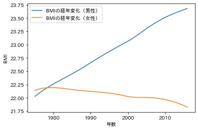

```python
plt.plot(Year, BMI_men, label="BMIの経年変化（男性）")
plt.plot(Year, BMI_women, label="BMIの経年変化（女性）")

plt.xlabel('年数')
plt.ylabel('BMI')

# 凡例の表示
plt.legend()

# プロット表示(設定の反映)
plt.show()
```

### **2.4 関数を自作する**

#### **関数の定義**

関数はdef文で定義する

```python
def add(x, y):
    return x + y


print(add(2, 5))
```

```
7
```

#### **クラス**

```python
class Dog:
    str = "I am a dog." # クラス変数
    def __init__(self, name, age): # コンストラクタ
        self.name = name # インスタンス変数
        self.age = age # インスタンス変数
    def introduce(self): # メソッド
        print("My name is " + self.name + ".  I'm " + self.age + "years old.")

dogA = Dog("Hachi", "3")
print(Dog.str)
print(dogA.name)
print(dogA.age)
dogA.introduce()
```

```
I am a dog.
Hachi
3
My name is Hachi.  I'm 3years old.
```

def __init__(self, name, age):

def __init__(self, 変数1, 変数2, ...):

def __init__(self, はおまじない．

メソッド def introduce(self): print("My name is " + self.name + ". I'm " + self.age + "years old.")

コンストラクタで定義した変数を使って，コードを実行する． この例ではprint文だが，計算も可能．

#### **コンストラクタの変数を増やしてみる**

```python
class Dog:
    def __init__(self, name, age, size):
        self.name = name
        self.age = age
        self.size = size

dogA = Dog("Hachi", "3", "Big")
print(dogA.name)
print(dogA.age)
print(dogA.size)
```

```
Hachi
3
Big
```

#### **メソッドを使って計算してみる**

```python
class BMI:
    def __init__(self, height, weight):
        self.h = height # インスタンス変数
        self.w = weight # インスタンス変数
    def BMI_calculation(self): # メソッド
       # BMIを計算する
        self.bmi = self.w / self.h ** 2
        print("私の身長と体重は" + str(self.h) + "(m), " + str(self.w) + "(kg), " "BMIは" + str(self.bmi) + "です．")

BMI_A = BMI(1.72, 59)
print(BMI_A.h)
print(BMI_A.w)
BMI_A.BMI_calculation()
```

```
1.72
59
私の身長と体重は1.72(m), 59(kg), BMIは19.94321254732288です．
```

#### **グラフ化するクラスを作成する**

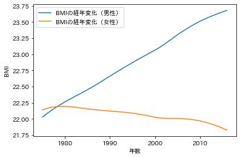

```python
import pandas as pd
import numpy as np
import matplotlib.pyplot as plt
import japanize_matplotlib


class BMI_plot:
    def __init__(self, Year, data, labels):
        self.Year = Year
        self.data = data
        self.labels = labels

    def plots(self):
        for data, labels in zip(self.data, self.labels):
            plt.plot(self.Year, data, label=labels)

        plt.xlabel('年数')
        plt.ylabel('BMI')
        # 凡例の表示
        plt.legend()
        # プロット表示(設定の反映)
        plt.show()



BMI_men_data = pd.read_csv('BMI_Men_JPN.csv', header=0)  # headerなしの場合はNone
BMI_women_data = pd.read_csv('BMI_Women_JPN.csv', header=0)  # headerなしの場合はNone

Year = pd.Series(BMI_men_data.Year, name='Year')
BMI_men = pd.Series(BMI_men_data.Mean_BMI, name='BMI')
BMI_women = pd.Series(BMI_women_data.Mean_BMI, name='BMI')

data = [BMI_men, BMI_women]
labels = ['BMIの経年変化（男性）', 'BMIの経年変化（女性）']

BMI_plots = BMI_plot(Year, data, labels)
BMI_plots.plots()
```

## **3. 機械学習**

### **3.1 scikit-learn**

scikit-learnはPythonで利用できる**機械学習ライブラリ**の１つ  
回帰（regression）や分類（classification）などの機械学習アルゴリズムを利用できる

#### **利用可能なアルゴリズム**

・線形回帰（最小二乗法）  
・ロジスティック回帰  
・L2正則化 線形回帰 (リッジ回帰)  
・L1正則化 線形回帰 (ラッソ回帰)  
・Elastic Net回帰  
・サポートベクターマシーン(SVM)  
・回帰木  
・ランダムフォレスト  
・勾配ブースティング  
など

#### **利用できるサンプルデータ**

・bostonの住宅価格データセット  
・アイリス（アヤメ）のデータセット  
・ウィスコンシン州の乳がんのデータセット  
・糖尿病の診断のデータセット  
・ワインの種類のデータセット  
・手書き文字の認識のデータセット  
・生理学的特徴と運動能力のデータセット

### **3.2 サンプルデータセットの読み込み**

```python
import pandas as pd
# bostonの住宅価格データセットの読み込み
from sklearn.datasets import load_boston

dataset = load_boston()
```

```python
print(dataset.data)
```

```
[[6.3200e-03 1.8000e+01 2.3100e+00 ... 1.5300e+01 3.9690e+02 4.9800e+00]
 [2.7310e-02 0.0000e+00 7.0700e+00 ... 1.7800e+01 3.9690e+02 9.1400e+00]
 [2.7290e-02 0.0000e+00 7.0700e+00 ... 1.7800e+01 3.9283e+02 4.0300e+00]
 ...
 [6.0760e-02 0.0000e+00 1.1930e+01 ... 2.1000e+01 3.9690e+02 5.6400e+00]
 [1.0959e-01 0.0000e+00 1.1930e+01 ... 2.1000e+01 3.9345e+02 6.4800e+00]
 [4.7410e-02 0.0000e+00 1.1930e+01 ... 2.1000e+01 3.9690e+02 7.8800e+00]]
```

```python
print(dataset.feature_names)
```

```
['CRIM' 'ZN' 'INDUS' 'CHAS' 'NOX' 'RM' 'AGE' 'DIS' 'RAD' 'TAX' 'PTRATIO'
 'B' 'LSTAT']
```

CRIM：町の人口当たり犯罪率  
ZN：25,000平方フィート以上の区域の宅地比率  
INDUS：町の小売り以外の産業用の土地比率  
CHAS：チャールズ川ダミー変数（1：川沿い，0：それ以外）  
NOX：NOx濃度（10ppm単位）  
RM：1戸あたり部屋数  
AGE：1940年以前に建築された持家住宅の比率  
DIS：ボストンにある5つの職業紹介所への重みづけ距離  
RAD：道路（放射線）へのアクセスのしやすさ  
TAX：10,000ドルあたりの固定資産税の総額  
PTRATIO：生徒対教師の比率  
B：1000(Bk – 0.63)^2（Bkは黒人比率）  
LSTAT：下位層の人口比率(%)

```python
# set dataframe
X = pd.DataFrame(dataset.data, columns=dataset.feature_names)
y = pd.Series(dataset.target, name='MEDV')
```

```python
# データの確認
display(X.join(y).head())
print('--------------------------------------')
print('（データ数， 特徴量数）: (%i,%i)' %X.shape)
print('--------------------------------------')
```

|  | CRIM | ZN | INDUS | CHAS | NOX | RM | AGE | DIS | RAD | TAX | PTRATIO | B | LSTAT | MEDV |
| --- | --- | --- | --- | --- | --- | --- | --- | --- | --- | --- | --- | --- | --- | --- |
| 0 | 0.00632 | 18.0 | 2.31 | 0.0 | 0.538 | 6.575 | 65.2 | 4.0900 | 1.0 | 296.0 | 15.3 | 396.90 | 4.98 | 24.0 |
| 1 | 0.02731 | 0.0 | 7.07 | 0.0 | 0.469 | 6.421 | 78.9 | 4.9671 | 2.0 | 242.0 | 17.8 | 396.90 | 9.14 | 21.6 |
| 2 | 0.02729 | 0.0 | 7.07 | 0.0 | 0.469 | 7.185 | 61.1 | 4.9671 | 2.0 | 242.0 | 17.8 | 392.83 | 4.03 | 34.7 |
| 3 | 0.03237 | 0.0 | 2.18 | 0.0 | 0.458 | 6.998 | 45.8 | 6.0622 | 3.0 | 222.0 | 18.7 | 394.63 | 2.94 | 33.4 |
| 4 | 0.06905 | 0.0 | 2.18 | 0.0 | 0.458 | 7.147 | 54.2 | 6.0622 | 3.0 | 222.0 | 18.7 | 396.90 | 5.33 | 36.2 |

```
--------------------------------------
（データ数， 特徴量数）: (506,13)
--------------------------------------
```

```python
print(y)
```

```
0      24.0
1      21.6
2      34.7
3      33.4
4      36.2
       ...
501    22.4
502    20.6
503    23.9
504    22.0
505    11.9
Name: MEDV, Length: 506, dtype: float64
```

MEDV : 持家住宅の中央価格($1000単位)  
このデータセットではこれを目的変数とする

#### **describe()：データの基本統計量**

```python
print(y.describe())
```

```
count    506.000000
mean      22.532806
std        9.197104
min        5.000000
25%       17.025000
50%       21.200000
75%       25.000000
max       50.000000
Name: MEDV, dtype: float64
```

#### **display関数を使ってテーブル表示**

```python
# join()は()内の要素（列）を追加する （目的変数も同時に表示するため）
display(X.join(y))
```

|  | CRIM | ZN | INDUS | CHAS | NOX | RM | AGE | DIS | RAD | TAX | PTRATIO | B | LSTAT | MEDV |
| --- | --- | --- | --- | --- | --- | --- | --- | --- | --- | --- | --- | --- | --- | --- |
| 0 | 0.00632 | 18.0 | 2.31 | 0.0 | 0.538 | 6.575 | 65.2 | 4.0900 | 1.0 | 296.0 | 15.3 | 396.90 | 4.98 | 24.0 |
| 1 | 0.02731 | 0.0 | 7.07 | 0.0 | 0.469 | 6.421 | 78.9 | 4.9671 | 2.0 | 242.0 | 17.8 | 396.90 | 9.14 | 21.6 |
| 2 | 0.02729 | 0.0 | 7.07 | 0.0 | 0.469 | 7.185 | 61.1 | 4.9671 | 2.0 | 242.0 | 17.8 | 392.83 | 4.03 | 34.7 |
| 3 | 0.03237 | 0.0 | 2.18 | 0.0 | 0.458 | 6.998 | 45.8 | 6.0622 | 3.0 | 222.0 | 18.7 | 394.63 | 2.94 | 33.4 |
| 4 | 0.06905 | 0.0 | 2.18 | 0.0 | 0.458 | 7.147 | 54.2 | 6.0622 | 3.0 | 222.0 | 18.7 | 396.90 | 5.33 | 36.2 |
| ... | ... | ... | ... | ... | ... | ... | ... | ... | ... | ... | ... | ... | ... | ... |
| 501 | 0.06263 | 0.0 | 11.93 | 0.0 | 0.573 | 6.593 | 69.1 | 2.4786 | 1.0 | 273.0 | 21.0 | 391.99 | 9.67 | 22.4 |
| 502 | 0.04527 | 0.0 | 11.93 | 0.0 | 0.573 | 6.120 | 76.7 | 2.2875 | 1.0 | 273.0 | 21.0 | 396.90 | 9.08 | 20.6 |
| 503 | 0.06076 | 0.0 | 11.93 | 0.0 | 0.573 | 6.976 | 91.0 | 2.1675 | 1.0 | 273.0 | 21.0 | 396.90 | 5.64 | 23.9 |
| 504 | 0.10959 | 0.0 | 11.93 | 0.0 | 0.573 | 6.794 | 89.3 | 2.3889 | 1.0 | 273.0 | 21.0 | 393.45 | 6.48 | 22.0 |
| 505 | 0.04741 | 0.0 | 11.93 | 0.0 | 0.573 | 6.030 | 80.8 | 2.5050 | 1.0 | 273.0 | 21.0 | 396.90 | 7.88 | 11.9 |

506 rows × 14 columns

### **3.3 Regression（回帰）**

ここではモデル構築の大きな流れを掴みましょう。まずは、サンプルデータ（回帰用）を読み込みます。

```python
import pandas as pd #pandas ライブリラの読み込み
from sklearn.datasets import load_iris # アイリスデータセット（花のデータセット）の読み込み

#アイリスデータセットをロードし，dataset変数に代入する
dataset = load_iris()
# datasetの中身を確認する
print(dataset)
```

[output not shown]

[output cut: 101 more lines]

[output not shown]

```python
# datasetの中身を表示する
print(dataset.keys())
```

```
dict_keys(['data', 'target', 'frame', 'target_names', 'DESCR', 'feature_names', 'filename'])
```

```python
# datasetの'data'(説明変数；特徴量) を確認する
# 150行あるため，データフレーム形式で表示させる
pd.DataFrame(dataset.data)
```

|  | 0 | 1 | 2 | 3 |
| --- | --- | --- | --- | --- |
| 0 | 5.1 | 3.5 | 1.4 | 0.2 |
| 1 | 4.9 | 3.0 | 1.4 | 0.2 |
| 2 | 4.7 | 3.2 | 1.3 | 0.2 |
| 3 | 4.6 | 3.1 | 1.5 | 0.2 |
| 4 | 5.0 | 3.6 | 1.4 | 0.2 |
| ... | ... | ... | ... | ... |
| 145 | 6.7 | 3.0 | 5.2 | 2.3 |
| 146 | 6.3 | 2.5 | 5.0 | 1.9 |
| 147 | 6.5 | 3.0 | 5.2 | 2.0 |
| 148 | 6.2 | 3.4 | 5.4 | 2.3 |
| 149 | 5.9 | 3.0 | 5.1 | 1.8 |

150 rows × 4 columns

```python
# datasetの'target'(目的変数)を確認する
# 150行あるため，データフレーム形式で表示させる
pd.DataFrame(dataset.target)
```

|  | 0 |
| --- | --- |
| 0 | 0 |
| 1 | 0 |
| 2 | 0 |
| 3 | 0 |
| 4 | 0 |
| ... | ... |
| 145 | 2 |
| 146 | 2 |
| 147 | 2 |
| 148 | 2 |
| 149 | 2 |

150 rows × 1 columns

```python
# dataset.feature_names には　説明変数（特徴量）名が含まれている．
print(dataset.feature_names)
```

```
['sepal length (cm)', 'sepal width (cm)', 'petal length (cm)', 'petal width (cm)']
```

```python
# データセットの解説がみられる
print(dataset.DESCR)
```

```
.. _iris_dataset:

Iris plants dataset
--------------------

**Data Set Characteristics:**

    :Number of Instances: 150 (50 in each of three classes)
    :Number of Attributes: 4 numeric, predictive attributes and the class
    :Attribute Information:
        - sepal length in cm
        - sepal width in cm
        - petal length in cm
        - petal width in cm
        - class:
                - Iris-Setosa
                - Iris-Versicolour
                - Iris-Virginica

    :Summary Statistics:

    ============== ==== ==== ======= ===== ====================
                    Min  Max   Mean    SD   Class Correlation
    ============== ==== ==== ======= ===== ====================
    sepal length:   4.3  7.9   5.84   0.83    0.7826
    sepal width:    2.0  4.4   3.05   0.43   -0.4194
    petal length:   1.0  6.9   3.76   1.76    0.9490  (high!)
    petal width:    0.1  2.5   1.20   0.76    0.9565  (high!)
    ============== ==== ==== ======= ===== ====================

    :Missing Attribute Values: None
    :Class Distribution: 33.3% for each of 3 classes.
    :Creator: R.A. Fisher
    :Donor: Michael Marshall (MARSHALL%PLU@io.arc.nasa.gov)
    :Date: July, 1988

The famous Iris database, first used by Sir R.A. Fisher. The dataset is taken
from Fisher's paper. Note that it's the same as in R, but not as in the UCI
Machine Learning Repository, which has two wrong data points.

```

[output cut: 8 more lines]

```

   - Fisher, R.A. "The use of multiple measurements in taxonomic problems"
     Annual Eugenics, 7, Part II, 179-188 (1936); also in "Contributions to
     Mathematical Statistics" (John Wiley, NY, 1950).
   - Duda, R.O., & Hart, P.E. (1973) Pattern Classification and Scene Analysis.
     (Q327.D83) John Wiley & Sons.  ISBN 0-471-22361-1.  See page 218.
   - Dasarathy, B.V. (1980) "Nosing Around the Neighborhood: A New System
     Structure and Classification Rule for Recognition in Partially Exposed
     Environments".  IEEE Transactions on Pattern Analysis and Machine
     Intelligence, Vol. PAMI-2, No. 1, 67-71.
   - Gates, G.W. (1972) "The Reduced Nearest Neighbor Rule".  IEEE Transactions
     on Information Theory, May 1972, 431-433.
   - See also: 1988 MLC Proceedings, 54-64.  Cheeseman et al"s AUTOCLASS II
     conceptual clustering system finds 3 classes in the data.
   - Many, many more ...
```

```python
# irisデータセットの場所
print(dataset.filename)
```

```
/Users/hironao/anaconda3/lib/python3.9/site-packages/sklearn/datasets/data/iris.csv
```

```python
# Xという変数に説明変数（特徴量）をデータフレームの形で代入する．columnsで列名を設定する．
X = pd.DataFrame(dataset.data, columns=dataset.feature_names)
X
```

|  | sepal length (cm) | sepal width (cm) | petal length (cm) | petal width (cm) |
| --- | --- | --- | --- | --- |
| 0 | 5.1 | 3.5 | 1.4 | 0.2 |
| 1 | 4.9 | 3.0 | 1.4 | 0.2 |
| 2 | 4.7 | 3.2 | 1.3 | 0.2 |
| 3 | 4.6 | 3.1 | 1.5 | 0.2 |
| 4 | 5.0 | 3.6 | 1.4 | 0.2 |
| ... | ... | ... | ... | ... |
| 145 | 6.7 | 3.0 | 5.2 | 2.3 |
| 146 | 6.3 | 2.5 | 5.0 | 1.9 |
| 147 | 6.5 | 3.0 | 5.2 | 2.0 |
| 148 | 6.2 | 3.4 | 5.4 | 2.3 |
| 149 | 5.9 | 3.0 | 5.1 | 1.8 |

150 rows × 4 columns

```python
# yという変数に目的変数をデータフレームの形で代入する．columnsで列名を設定する．
y = pd.Series(dataset.target, name='type')
y
```

```
0      0
1      0
2      0
3      0
4      0
      ..
145    2
146    2
147    2
148    2
149    2
Name: type, Length: 150, dtype: int64
```

```python
print('y:目的変数（0, 1, 2）のそれぞれの数をカウントする')
print(y.value_counts())
print('0: setosa（セトサ）種')
print('1: versicolor（バージカラー）種')
print('2: virginica（バージニカ）種')
```

```
y:目的変数（0, 1, 2）のそれぞれの数をカウントする
0    50
1    50
2    50
Name: type, dtype: int64
0: setosa（セトサ）種
1: versicolor（バージカラー）種
2: virginica（バージニカ）種
```

### **3.4 回帰とは**

#### **重回帰分析**

説明変数 $x_1,x_2,x_3,⋯,x_m$  
予測値（回帰モデル） $ŷ$  
回帰係数 $w_1,w_2,w_3,⋯,w_m$

回帰モデル $ŷ =w_1x_1+w_2x_2+⋯+w_mx_m$

アイリスデータセットの場合  
説明変数は4個  
$x_1$ : がくの長さ(Sepal Length)  
$x_2$ :がくの幅 (Sepal Width)  
$x_3$ :花びらの長さ (Petal Length)  
$x_4$ :花びらの幅 (Petal Width)

目的変数 $y$ 150データ  
0: setosa（セトサ）種 50データ  
1: versicolor（バージカラー）種 50データ  
2: virginica（バージニカ）種 50データ

$y$ と $x_1$, $x_2$, $x_3$, $x_4$ を用いて回帰係数$w_1,w_2,w_3,w_4$を求められれば，回帰モデル$ŷ$を導ける  
*解き方の詳細は教科書等で確認してください

#### **Ridge回帰を使ってモデルを作成してみる**

```python
import matplotlib.pyplot as plt # プロットライブラリ
import japanize_matplotlib # プロット日本語対応ライブラリ
from sklearn.model_selection import train_test_split #データを訓練とテストに分割するための関数
from sklearn.linear_model import Ridge # Ridge回帰
from sklearn.datasets import load_iris # アイリスデータセット（花のデータセット）の読み込み
from sklearn.metrics import r2_score # 決定係数を計算する関数を読み込む

#アイリスデータセットをロードし，dataset変数に代入する
dataset = load_iris()

# データセットから説明変数と目的変数を抽出
# Xという変数に説明変数（特徴量）をデータフレームの形で代入する．columnsで列名を設定する．
X = pd.DataFrame(dataset.data, columns=dataset.feature_names)
# yという変数に目的変数をデータフレームの形で代入する．columnsで列名を設定する．
y = pd.Series(dataset.target, name='type')

# データを訓練とテストに分割
# random_stateは乱数の種
# test_sizeは訓練データとテストデータの分割の比率
X_train, X_test, y_train, y_test = train_test_split(X, y, random_state=1, test_size=0.25)

# Ridge回帰関数をridge変数に代入
# alphaはL2正則項の調節
# alphaの値を0にすると最小二乗法と同じモデルになる
# max_iterは計算回数の最大値
ridge = Ridge(alpha=0.1, max_iter=10000)

# .fit(モデル訓練用説明変数（特徴量），　モデル訓練用目的変数)でモデル訓練する．
ridge.fit(X_train, y_train)

# 性能（正答率）評価
print(f"訓練に対しての精度: {ridge.score(X_train, y_train):.3f}")
print(f"テストに対しての精度: {ridge.score(X_test, y_test):.3f}")

#r2_score関数による性能（正答率）評価
print('Test Ridge:%.6f'% r2_score(y_test, ridge.predict(X_test)))
```

```
訓練に対しての精度: 0.934
テストに対しての精度: 0.899
Test Ridge:0.899414
```

### **3.5 重要な説明変数（特徴量）が何であるかを可視化**

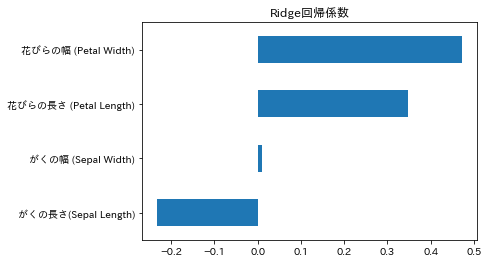

```python
# 説明変数（特徴量）をfeat_namesに代入
feat_names = ['がくの長さ(Sepal Length)', 'がくの幅 (Sepal Width)', '花びらの長さ (Petal Length)', '花びらの幅 (Petal Width)']

# 訓練したモデルの回帰係数 ridge.coef_ を pandas Series型としてcoefに代入．feat_namesを使ってそれぞれにindex名を付ける．
coef = pd.Series(ridge.coef_, index = feat_names)

# 回帰係数が大きい順にソート
imp_coef = coef.sort_values()

# 水平棒グラフ
imp_coef.plot(kind = "barh")

# タイトルを付ける
plt.title("Ridge回帰係数");
```

#### **ボストンの宅地価格データセットを使って最小二乗法，Rigde回帰，Lasso回帰，ElasticNet回帰を実行してみる**

```python
# import the data for regression
import pandas as pd
from sklearn.datasets import load_boston
dataset = load_boston()
from sklearn.model_selection import train_test_split

# データセットから説明変数と目的変数を抽出
# Xという変数に説明変数（特徴量）をデータフレームの形で代入する．columnsで列名を設定する．
# yという変数に目的変数をデータフレームの形で代入する．columnsで列名を設定する．
X = pd.DataFrame(dataset.data,columns=dataset.feature_names)
y = pd.Series(dataset.target,name='y')

# データを訓練とテストに分割
X_train, X_test, y_train, y_test = train_test_split(X, y, random_state=1)

# データの確認
display(X.join(y).head())
print('--------------------------------------')
print('（データ数， 特徴量数）: (%i,%i)' %X.shape)
print('--------------------------------------')
```

|  | CRIM | ZN | INDUS | CHAS | NOX | RM | AGE | DIS | RAD | TAX | PTRATIO | B | LSTAT | y |
| --- | --- | --- | --- | --- | --- | --- | --- | --- | --- | --- | --- | --- | --- | --- |
| 0 | 0.00632 | 18.0 | 2.31 | 0.0 | 0.538 | 6.575 | 65.2 | 4.0900 | 1.0 | 296.0 | 15.3 | 396.90 | 4.98 | 24.0 |
| 1 | 0.02731 | 0.0 | 7.07 | 0.0 | 0.469 | 6.421 | 78.9 | 4.9671 | 2.0 | 242.0 | 17.8 | 396.90 | 9.14 | 21.6 |
| 2 | 0.02729 | 0.0 | 7.07 | 0.0 | 0.469 | 7.185 | 61.1 | 4.9671 | 2.0 | 242.0 | 17.8 | 392.83 | 4.03 | 34.7 |
| 3 | 0.03237 | 0.0 | 2.18 | 0.0 | 0.458 | 6.998 | 45.8 | 6.0622 | 3.0 | 222.0 | 18.7 | 394.63 | 2.94 | 33.4 |
| 4 | 0.06905 | 0.0 | 2.18 | 0.0 | 0.458 | 7.147 | 54.2 | 6.0622 | 3.0 | 222.0 | 18.7 | 396.90 | 5.33 | 36.2 |

```
--------------------------------------
（データ数， 特徴量数）: (506,13)
--------------------------------------
```

#### **線形回帰（最小二乗法）：OLS**

```python
from sklearn.linear_model import LinearRegression # 線形回帰（最小二乗法）
from sklearn.metrics import r2_score

# 線形回帰を定義
ols = LinearRegression()
# モデルの学習
ols.fit(X_train, y_train)

# 性能（正答率）評価
print(f"Training dataに対しての精度: {ols.score(X_train, y_train):.2}")
print(f"Test set scoreに対しての精度: {ols.score(X_test, y_test):.2f}")

#r2_score関数による性能（正答率）評価
print('Test OLS:%.6f'% r2_score(y_test, ols.predict(X_test)))
```

```
Training dataに対しての精度: 0.72
Test set scoreに対しての精度: 0.78
Test OLS:0.778941
```

#### **Lasso回帰**

```python
from sklearn.linear_model import Lasso # Lasso回帰

# Lasso回帰を定義
l = Lasso(alpha=0.5, max_iter=10000)
# モデルの学習
l.fit(X_train, y_train)

# 性能（正答率）評価
print(f"Training dataに対しての精度: {l.score(X_train, y_train):.2}")
print(f"Test set scoreに対しての精度: {l.score(X_test, y_test):.2f}")

#r2_score関数による性能（正答率）評価
print('Test Lasso:%.6f'% r2_score(y_test, l.predict(X_test)))
```

```
Training dataに対しての精度: 0.68
Test set scoreに対しての精度: 0.73
Test Lasso:0.733130
```

#### **Rigde回帰**

```python
from sklearn.linear_model import Ridge # Ridge回帰

# Rigde回帰を定義
ridge = Ridge(alpha=0.5, max_iter=10000)
# モデルの学習
ridge.fit(X_train, y_train)

# 性能（正答率）評価
print(f"Training dataに対しての精度: {ridge.score(X_train, y_train):.2}")
print(f"Test set scoreに対しての精度: {ridge.score(X_test, y_test):.2f}")

#r2_score関数による性能（正答率）評価
print('Test Ridge:%.6f'% r2_score(y_test, ridge.predict(X_test)))
```

```
Training dataに対しての精度: 0.72
Test set scoreに対しての精度: 0.78
Test Ridge:0.783496
```

```python
print('lassoとridgeの回帰係数')
print(l.coef_)
print(ridge.coef_)
```

```
lassoとridgeの回帰係数
[-0.0882369   0.05800307 -0.01636258  0.         -0.          1.59485829
  0.00668738 -0.86844824  0.26752545 -0.01377449 -0.75401407  0.00690801
 -0.68798193]
[-1.11088561e-01  5.77695150e-02  9.13527911e-03  2.27448929e+00
 -1.48915693e+01  2.94144764e+00  1.57940613e-03 -1.38335060e+00
  2.93199807e-01 -1.13729101e-02 -9.20654401e-01  6.65508760e-03
 -5.64235128e-01]
```

Lassoは、特徴量を０として処理したのもあったのに対し，Ridgeでは特徴を切り捨てることなく利用している．

これがLassoとRidgeの違いであり，

Lassoではパラメータの圧縮＝判断に用いる特徴量の選択を行うが，Ridgeでは行わない．

どの特徴量がグラフに影響を与えているのかを見つけるにはLassoが便利である．

過学習を抑えつつ相関を見つけたいならばRidgeを利用する．

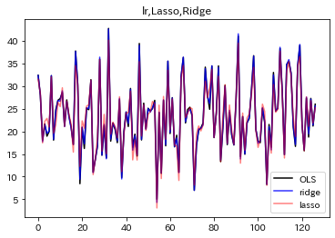

```python
#直線回帰、ラッソ回帰、リッジ回帰で算出されたモデル関数を図示
plt.plot(ols.predict(X_test), linestyle="solid",
         color="black",label="OLS")
plt.plot(ridge.predict(X_test), linestyle="solid",
         color="blue", label='ridge', alpha=0.8)
plt.plot(l.predict(X_test), linestyle="solid",
         color="red", label="lasso", alpha=0.5)
plt.title("lr,Lasso,Ridge")
plt.legend(loc="lower right")
plt.show()
```

直線(OLS)回帰，Lasso回帰，Rigde回帰で求められたモデル関数の図示． 黒が直線回帰，赤がLasso，青がRidge．

LassoとRidgeのグラフを見比べると，Lassoの方が線のブレが若干小さい． これは，Lassoがパラメータの圧縮を行なっているためである．

#### **Elastic Net回帰**

```python
from sklearn.linear_model import ElasticNet

# ElasticNet回帰を定義
En = ElasticNet(alpha = 0.1, max_iter=10000)
# モデルの学習
En.fit(X_train, y_train)

# 性能（正答率）評価
print(f"Training dataに対しての精度: {En.score(X_train, y_train):.2}")
print(f"Test set scoreに対しての精度: {En.score(X_test, y_test):.2f}")

#r2_score関数による性能（正答率）評価
print('Test ElasticNet:%.6f'% r2_score(y_test, En.predict(X_test)))
```

```
Training dataに対しての精度: 0.7
Test set scoreに対しての精度: 0.77
Test ElasticNet:0.768872
```

```python
print('lassoとridge，Elastic Netの回帰係数')
print(l.coef_)
print(ridge.coef_)
print(En.coef_)
```

```
lassoとridge，Elastic Netの回帰係数
[-0.0882369   0.05800307 -0.01636258  0.         -0.          1.59485829
  0.00668738 -0.86844824  0.26752545 -0.01377449 -0.75401407  0.00690801
 -0.68798193]
[-1.11088561e-01  5.77695150e-02  9.13527911e-03  2.27448929e+00
 -1.48915693e+01  2.94144764e+00  1.57940613e-03 -1.38335060e+00
  2.93199807e-01 -1.13729101e-02 -9.20654401e-01  6.65508760e-03
 -5.64235128e-01]
[-0.10345952  0.06094263 -0.0509648   0.85138958 -0.26549994  2.5284661
 -0.00435042 -1.13533818  0.28271639 -0.01384449 -0.77578499  0.00738778
 -0.62132992]
```

ElasticNetは，全ての特徴量を利用するRidgeと一部切り捨てるLassoを組み合わせていることがわかる．

### **3.6 予測性能の可視化**

```python
import pandas as pd
from sklearn.datasets import load_boston
import matplotlib.pyplot as plt
import japanize_matplotlib

# データセットから説明変数と目的変数を抽出
dataset = load_boston()
X = pd.DataFrame(dataset.data,columns=dataset.feature_names)
y = pd.Series(dataset.target,name='y')

# データを訓練とテストに分割
X_train, X_test, y_train, y_test = train_test_split(X, y, random_state=1)
```

#### **モデル作成と実測値vs予測値プロット（決定係数の可視化）**

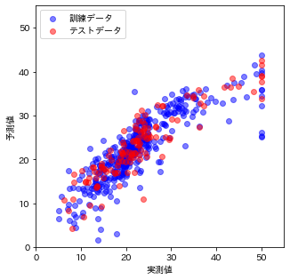

```python
ridge = Ridge(alpha=0.5, max_iter=10000)
ridge.fit(X_train, y_train)
y_ridge_pred = ridge.predict(X_test)
y_ridge_pred_train = ridge.predict(X_train)

plt.figure()
plt.figure(figsize=(5,5))
plt.xlim([0, 55.0])
plt.ylim([0, 55.0])
plt.scatter(y_train, y_ridge_pred_train, color='blue', alpha=0.5, label='訓練データ')
plt.scatter(y_test, y_ridge_pred, color='red', alpha=0.5, label='テストデータ')
plt.xlabel('実測値')
plt.ylabel('予測値')
plt.legend(loc='upper left')
```

実測値と予測値がy=xの直線上に乗っているほど予測精度が高いモデルが作成できている．

### **3.7 Classification（分類）**

#### **ロジスティック回帰**

```python
from sklearn import datasets # データセット
from sklearn.metrics import accuracy_score # 分類評価の関数
from sklearn.model_selection import train_test_split # 分割
from sklearn.linear_model import LogisticRegression # ロジスティック回帰

# データの読み込み
iris = datasets.load_iris()
x, y = iris.data, iris.target

# トレーニングデータとテストデータに分ける
x_train, x_test, y_train, y_test = train_test_split(x, y, random_state=1)

# モデルの選択
lr = LogisticRegression(max_iter=10000) # ロジスティック回帰モデルのインスタンスを作成
# 学習
lr.fit(x_train, y_train) # ロジスティック回帰モデルの重みを学習

# テストと評価
pred = lr.predict(x_test)
print(accuracy_score(y_test, pred))

# 学習済みモデルを使う
print(lr.predict([[1.4, 3.5, 5.1, 0.2], [6.5, 2.6, 4.4, 1.4], [5.9, 3.0, 5.2, 1.5]]))

#がくの長さ(Sepal Length):1.4
#がくの幅 (Sepal Width):3.5
#花びらの長さ (Petal Length):5.1
#花びらの幅 (Petal Width):0.2
```

```
0.9736842105263158
[2 1 2]
```

#### **サポートベクターマシーン（SVM）**

```python
from sklearn.svm import SVC

# データの読み込み
iris = datasets.load_iris()
x, y = iris.data, iris.target

# トレーニングデータとテストデータに分ける
x_train, x_test, y_train, y_test = train_test_split(x, y, random_state=1)

# モデルの選択
model = SVC(max_iter=10000)
# model = RandomForestClassifier()
# 学習
model.fit(x_train, y_train)

# テストと評価
pred = model.predict(x_test)
print(accuracy_score(y_test, pred))

# 学習済みモデルを使う
print(model.predict([[1.4, 3.5, 5.1, 0.2], [6.5, 2.6, 4.4, 1.4], [5.9, 3.0, 5.2, 1.5]]))

#がくの長さ(Sepal Length):1.4
#がくの幅 (Sepal Width):3.5
#花びらの長さ (Petal Length):5.1
#花びらの幅 (Petal Width):0.2
```

```
0.9736842105263158
[2 1 2]
```

#### **k近傍法**

```python
from sklearn.neighbors import KNeighborsClassifier

# データの読み込み
iris = datasets.load_iris()
x, y = iris.data, iris.target

# トレーニングデータとテストデータに分ける
x_train, x_test, y_train, y_test = train_test_split(x, y, random_state=1)

# モデルの選択
knn = KNeighborsClassifier(n_neighbors=4)
knn.fit(x_train, y_train)

# テストと評価
pred = knn.predict(x_test)
print(accuracy_score(y_test, pred))

# 学習済みモデルを使う
print(knn.predict([[1.4, 3.5, 5.1, 0.2], [6.5, 2.6, 4.4, 1.4], [5.9, 3.0, 5.2, 1.5]]))

#がくの長さ(Sepal Length):1.4
#がくの幅 (Sepal Width):3.5
#花びらの長さ (Petal Length):5.1
#花びらの幅 (Petal Width):0.2
```

```
1.0
[1 1 2]
```

### **3.8 可視化**

#### **モデル作成の準備**

```python
import numpy as np # Numpy
import math # math
from sklearn import datasets # データセット
from sklearn.model_selection import train_test_split # 分割
from sklearn.preprocessing import StandardScaler # 正規化
from sklearn.linear_model import LogisticRegression # ロジスティック回帰
import matplotlib.pyplot as plt # プロット
from matplotlib.colors import ListedColormap # カラーマップ

# データの取得
dataset = load_iris()
X = dataset.data
y = dataset.target

# 2変数によるだけを抽出
X = X[:, [0,1]]

# 入力データの各変数が平均0,標準偏差1になるように正規化
# 各アルゴリズムのプロット結果を比較しやすいように予め全入力データを正規化
sc = StandardScaler()
sc.fit(X)
X = sc.transform(X)

# データを学習用/テスト用に分割
x_train, x_test, y_train, y_test = train_test_split(X, y, random_state=1)
```

#### **可視化コード**

[output not shown]

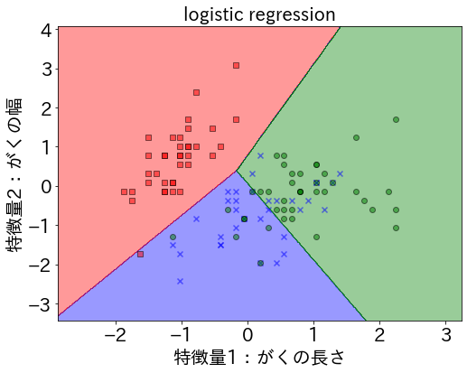

```python
# それぞれのモデルにおいて決定境界をプロット
plt.figure(figsize=(8,6))

# 被説明変数が3クラス（0, 1, 2）なので散布図のマーカータイプと色を3種類用意
# クラスの種類数に応じて拡張可能
markers = ('s', 'x', 'o')
cmap = ListedColormap(('red', 'blue', 'green'))

# xに訓練用の特徴量を定義
x = x_train
# メッシュ幅の設定
resolution=0.01

# 2変数の入力データの最小値から最大値まで引数resolutionの幅でメッシュを描く
x1_min, x1_max = x[:, 0].min()-1, x[:, 0].max()+1
x2_min, x2_max = x[:, 1].min()-1, x[:, 1].max()+1
x1_mesh, x2_mesh = np.meshgrid(np.arange(x1_min, x1_max, resolution),
                               np.arange(x2_min, x2_max, resolution))

# 機械学習アルゴリズムの定義
lr = LogisticRegression()
# モデルの学習
lr.fit(x_train, y_train)

## メッシュデータ全部を学習モデルで分類
z = lr.predict(np.array([x1_mesh.ravel(), x2_mesh.ravel()]).T)
z = z.reshape(x1_mesh.shape)

#ravel関数は、多次元のリストを1次元のリストにして返す．

## メッシュデータと分離クラスを使って決定境界を描いている
plt.contourf(x1_mesh, x2_mesh, z, alpha=0.4, cmap=cmap)
plt.xlim(x1_mesh.min(), x1_mesh.max())
plt.ylim(x2_mesh.min(), x2_mesh.max())

# yに訓練用の目的変数を定義
y = y_train

# プロット
for idx, cl in enumerate(np.unique(y)):
    plt.scatter(x=x[y == cl, 0],
                y=x[y == cl, 1],
                alpha=0.5,
                c=cmap(idx),
                edgecolors='black',
                marker=markers[idx],
                label=cl)

# タイトルやラベル
plt.title('logistic regression', fontsize=20)
plt.xlabel('特徴量1：がくの長さ', fontsize=20)
plt.ylabel('特徴量2：がくの幅', fontsize=20)
plt.tick_params(labelsize=20)
plt.show()
```

### **3.9 アンサンブル学習**

#### **randomforest**

```python
# 必要なライブラリのインポート
import pandas as pd # pandas
from sklearn.datasets import load_boston # ボストン宅地価格のデータセット
import matplotlib.pyplot as plt # プロットライブラリ
import japanize_matplotlib # プロット日本語対応ライブラリ
from sklearn.model_selection import train_test_split #データを訓練とテストに分割するためのライブラリ
from sklearn.ensemble import RandomForestRegressor # ランダムフォレストのライブラリ

dataset = load_boston()
```

```python
# Xという変数に説明変数（特徴量）をデータフレームの形で代入する．columnsで列名を設定する．
X = pd.DataFrame(dataset.data, columns=dataset.feature_names)
X
```

|  | CRIM | ZN | INDUS | CHAS | NOX | RM | AGE | DIS | RAD | TAX | PTRATIO | B | LSTAT |
| --- | --- | --- | --- | --- | --- | --- | --- | --- | --- | --- | --- | --- | --- |
| 0 | 0.00632 | 18.0 | 2.31 | 0.0 | 0.538 | 6.575 | 65.2 | 4.0900 | 1.0 | 296.0 | 15.3 | 396.90 | 4.98 |
| 1 | 0.02731 | 0.0 | 7.07 | 0.0 | 0.469 | 6.421 | 78.9 | 4.9671 | 2.0 | 242.0 | 17.8 | 396.90 | 9.14 |
| 2 | 0.02729 | 0.0 | 7.07 | 0.0 | 0.469 | 7.185 | 61.1 | 4.9671 | 2.0 | 242.0 | 17.8 | 392.83 | 4.03 |
| 3 | 0.03237 | 0.0 | 2.18 | 0.0 | 0.458 | 6.998 | 45.8 | 6.0622 | 3.0 | 222.0 | 18.7 | 394.63 | 2.94 |
| 4 | 0.06905 | 0.0 | 2.18 | 0.0 | 0.458 | 7.147 | 54.2 | 6.0622 | 3.0 | 222.0 | 18.7 | 396.90 | 5.33 |
| ... | ... | ... | ... | ... | ... | ... | ... | ... | ... | ... | ... | ... | ... |
| 501 | 0.06263 | 0.0 | 11.93 | 0.0 | 0.573 | 6.593 | 69.1 | 2.4786 | 1.0 | 273.0 | 21.0 | 391.99 | 9.67 |
| 502 | 0.04527 | 0.0 | 11.93 | 0.0 | 0.573 | 6.120 | 76.7 | 2.2875 | 1.0 | 273.0 | 21.0 | 396.90 | 9.08 |
| 503 | 0.06076 | 0.0 | 11.93 | 0.0 | 0.573 | 6.976 | 91.0 | 2.1675 | 1.0 | 273.0 | 21.0 | 396.90 | 5.64 |
| 504 | 0.10959 | 0.0 | 11.93 | 0.0 | 0.573 | 6.794 | 89.3 | 2.3889 | 1.0 | 273.0 | 21.0 | 393.45 | 6.48 |
| 505 | 0.04741 | 0.0 | 11.93 | 0.0 | 0.573 | 6.030 | 80.8 | 2.5050 | 1.0 | 273.0 | 21.0 | 396.90 | 7.88 |

506 rows × 13 columns

CRIM：町の人口当たり犯罪率  
ZN：25,000平方フィート以上の区域の宅地比率  
INDUS：町の小売り以外の産業用の土地比率  
CHAS：チャールズ川ダミー変数（1：川沿い，0：それ以外）  
NOX：NOx濃度（10ppm単位）  
RM：1戸あたり部屋数  
AGE：1940年以前に建築された持家住宅の比率  
DIS：ボストンにある5つの職業紹介所への重みづけ距離  
RAD：道路（放射線）へのアクセスのしやすさ  
TAX：10,000ドルあたりの固定資産税の総額  
PTRATIO：生徒対教師の比率  
B：1000(Bk – 0.63)^2（Bkは黒人比率）  
LSTAT：下位層の人口比率(%)

```python
# yという変数に目的変数をデータフレームの形で代入する．columnsで列名を設定する．
# MEDV : 持家住宅の中央価格($1000単位)
y = pd.Series(dataset.target, name='MEDV')
y
```

```
0      24.0
1      21.6
2      34.7
3      33.4
4      36.2
       ...
501    22.4
502    20.6
503    23.9
504    22.0
505    11.9
Name: MEDV, Length: 506, dtype: float64
```

```python
# データを訓練とテストに分割
X_train, X_test, y_train, y_test = train_test_split(X, y, random_state=1, test_size=0.25)

# ランダムフォレスト関数をforest変数に代入
forest = RandomForestRegressor(n_estimators=100, max_depth=5, random_state=1)

# .fit(モデル訓練用説明変数（特徴量），　モデル訓練用目的変数)でモデル訓練する．
forest.fit(X_train, y_train)
```

```
RandomForestRegressor(max_depth=5, random_state=1)
```

#### **モデルが出来るているかの確認**

```python
from sklearn.metrics import r2_score # 評価関数ライブラリ

# 訓練したモデルに　.predict(テスト用説明変数(特徴量)) でテストデータの予測値をy_predに代入
y_pred = forest.predict(X_test)

# R2値を計算し，r2変数に代入
r2 = r2_score(y_test, y_pred)
print("R2値:", r2)
```

```
R2値: 0.8982056758680822
```

#### **Ridge回帰との予測比較**

```python
from sklearn.linear_model import Ridge # Ridge回帰

# Rigde回帰を定義
ridge = Ridge(alpha=0.5, max_iter=10000)
# モデルの学習
ridge.fit(X_train, y_train)

#r2_score関数による性能（正答率）評価
print('R2値（Ridge）:%.6f'% r2_score(y_test, ridge.predict(X_test)))
```

```
R2値（Ridge）:0.783496
```

#### **gradientboosting**

```python
import pandas as pd # pandas
from sklearn.datasets import load_boston # ボストン宅地価格のデータセット
import matplotlib.pyplot as plt # プロットライブラリ
import japanize_matplotlib # プロット日本語対応ライブラリ
from sklearn.model_selection import train_test_split #データを訓練とテストに分割するためのライブラリ
from sklearn.ensemble import GradientBoostingRegressor #　Gradient Boostingのライブラリ
from sklearn.metrics import r2_score # 評価関数ライブラリ

dataset = load_boston()

X = pd.DataFrame(dataset.data, columns=dataset.feature_names)
y = pd.Series(dataset.target, name='MEDV')

# データを訓練とテストに分割
X_train, X_test, y_train, y_test = train_test_split(X, y, random_state=1, test_size=0.25)


# GradientBoosting関数をxgb変数に代入
# max_depth:木の深さ, n_estimators:木の数
xgb = GradientBoostingRegressor(n_estimators=100, max_depth=5, random_state=1)

# .fit(モデル訓練用説明変数（特徴量），　モデル訓練用目的変数)でモデル訓練する．
xgb.fit(X_train,y_train)


# モデルが出来るているかの確認
# 訓練したモデルに　.predict(テスト用説明変数(特徴量)) でテストデータの予測値をy_predに代入
y_pred = xgb.predict(X_test)
# R2値を計算し，r2変数に代入
r2 = r2_score(y_test, y_pred)
print("R2値:", r2)
```

```
R2値: 0.909945531611032
```

アンサンブル学習（ランダムフォレスト（random forest）や勾配ブースティング（gradient boosting））は，通常の線形回帰による学習よりも良い性能のモデルを作成できる場合が多い

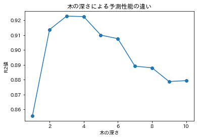

```python
from sklearn.metrics import r2_score # 評価関数ライブラリ
r2 = list()
depth_list = [1, 2, 3, 4, 5, 6, 7, 8, 9, 10]
for i in depth_list:
    xgb = GradientBoostingRegressor(n_estimators=100, max_depth=i, random_state=1)
    xgb.fit(X_train,y_train)
    y_pred = xgb.predict(X_test)
    r2.append(r2_score(y_test, y_pred))
plt.scatter(depth_list, r2)
plt.plot(depth_list, r2)
plt.ylabel("R2値")
plt.xlabel("木の深さ")
plt.title("木の深さによる予測性能の違い")
```

GradientBoostingRegressor(n_estimators="木の数", max_depth="木の深さ", random_state=1)  
木の深さや木の数は多ければいいわけではなく，その時その時によって最適の数がある  
これをハイパーパラメータチューニングと言う（詳しくは第12回目の演習で行う）

#### **決定木**

```python
import pandas as pd # pandas
from sklearn.datasets import load_breast_cancer # ヴィスコンシン州乳がんのデータセット
import matplotlib.pyplot as plt # プロットライブラリ
import japanize_matplotlib # プロット日本語対応ライブラリ
from sklearn.model_selection import train_test_split #データを訓練とテストに分割するためのライブラリ
from sklearn.tree import DecisionTreeClassifier #　決定木のライブラリ

# ヴィスコンシン州乳がんのデータセットをdatasetに代入
dataset = load_breast_cancer()

X = pd.DataFrame(dataset.data, columns=dataset.feature_names)
y = pd.Series(dataset.target, name='type')

# データを訓練とテストに分割
X_train, X_test, y_train, y_test = train_test_split(X, y, random_state=1)

# 決定木関数をdtc変数に代入
dtc = DecisionTreeClassifier(random_state=1)

# .fit(モデル訓練用説明変数（特徴量），　モデル訓練用目的変数)でモデル訓練する．
dtc.fit(X_train,y_train)

# モデルが出来るているかの確認
from sklearn.metrics import r2_score # 評価関数ライブラリ

# 訓練したモデルに　.predict(テスト用説明変数(特徴量)) でテストデータの予測値をy_predに代入
y_pred = dtc.predict(X_test)
# R2値を計算し，r2変数に代入
r2 = r2_score(y_test, y_pred)
print(r2)
```

#### **bagging**

```python
import pandas as pd # pandas
from sklearn.datasets import load_breast_cancer # ヴィスコンシン州乳がんのデータセット
import matplotlib.pyplot as plt # プロットライブラリ
import japanize_matplotlib # プロット日本語対応ライブラリ
from sklearn.model_selection import train_test_split #データを訓練とテストに分割するためのライブラリ
from sklearn.ensemble import BaggingClassifier #　Baggingのライブラリ
from sklearn.tree import DecisionTreeClassifier #　決定木のライブラリ

# ヴィスコンシン州乳がんのデータセットをdatasetに代入
dataset = load_breast_cancer()

X = pd.DataFrame(dataset.data, columns=dataset.feature_names)
y = pd.Series(dataset.target, name='type')

# データを訓練とテストに分割
X_train, X_test, y_train, y_test = train_test_split(X, y, random_state=1)

# bagging関数をbag変数に代入
bag = BaggingClassifier(DecisionTreeClassifier(random_state=1), n_estimators=100, random_state=1)

# 比較のためbaggingしないケースとして決定木関数をnobag変数に代入
nobag = DecisionTreeClassifier(random_state=1)


# .fit(モデル訓練用説明変数（特徴量），　モデル訓練用目的変数)でモデル訓練する．
bag.fit(X_train,y_train)
nobag.fit(X_train,y_train)


# モデルが出来るているかの確認
from sklearn.metrics import r2_score # 評価関数ライブラリ

# Baggingしたケース
# 訓練したモデルに　.predict(テスト用説明変数(特徴量)) でテストデータの予測値をy_predに代入
y_pred = bag.predict(X_test)
# R2値を計算し，r2変数に代入
r2 = r2_score(y_test, y_pred)
print(r2)

# Baggingしないケース
y_pred = nobag.predict(X_test)
# R2値を計算し，r2変数に代入
r2 = r2_score(y_test, y_pred)
print(r2)
```

#### **Boosting**

```python
import pandas as pd # pandas
from sklearn.datasets import load_breast_cancer # ヴィスコンシン州乳がんのデータセット
import matplotlib.pyplot as plt # プロットライブラリ
import japanize_matplotlib # プロット日本語対応ライブラリ
from sklearn.model_selection import train_test_split #データを訓練とテストに分割するためのライブラリ
from sklearn.ensemble import AdaBoostRegressor #　Boositingのライブラリ
from sklearn.tree import DecisionTreeRegressor #　決定木のライブラリ

# ヴィスコンシン州乳がんのデータセットをdatasetに代入
dataset = load_breast_cancer()

X = pd.DataFrame(dataset.data, columns=dataset.feature_names)
y = pd.Series(dataset.target, name='type')

# データを訓練とテストに分割
X_train, X_test, y_train, y_test = train_test_split(X, y, random_state=1)

# boosting関数をbst変数に代入
bst = AdaBoostRegressor(DecisionTreeRegressor(random_state=1), n_estimators=100, random_state=1)

# 比較のためboostingしないケースとして決定木関数をnobst変数に代入
nobst = DecisionTreeRegressor(random_state=1)


# .fit(モデル訓練用説明変数（特徴量），　モデル訓練用目的変数)でモデル訓練する．
bst.fit(X_train,y_train)
nobst.fit(X_train,y_train)


# モデルが出来るているかの確認
from sklearn.metrics import r2_score # 評価関数ライブラリ

# Boostingしたケース
# 訓練したモデルに　.predict(テスト用説明変数(特徴量)) でテストデータの予測値をy_predに代入
y_pred = bst.predict(X_test)
# R2値を計算し，r2変数に代入
r2 = r2_score(y_test, y_pred)
print(r2)

# Boostingしないケース
y_pred = nobst.predict(X_test)
# R2値を計算し，r2変数に代入
r2 = r2_score(y_test, y_pred)
print(r2)
```

## **4. モデル評価**

訓練データを使い，機械学習でモデルを作成した後，テストデータを使い「本当に良いモデルなのか？」という評価を必要があります．

### **4.1 分類の場合：AUCとROC**

二値分類の機械学習モデルのパフォーマンスを評価する

```python
import pandas as pd #pandas ライブリラの読み込み
from sklearn.datasets import load_breast_cancer # ヴィスコンシン州乳がんのデータセット
import matplotlib.pyplot as plt # プロットライブラリ
import japanize_matplotlib # プロット日本語対応ライブラリ
from sklearn.model_selection import train_test_split #データを訓練とテストに分割するためのライブラリ
from sklearn.svm import SVC # svmのライブラリ
from sklearn.metrics import roc_curve, auc # auc-roc ライブラリ

# ヴィスコンシン州乳がんのデータセットをdatasetに代入
dataset = load_breast_cancer()

X = pd.DataFrame(dataset.data, columns=dataset.feature_names)
y = pd.Series(dataset.target, name='type')

# データを訓練とテストに分割
X_train, X_test, y_train, y_test = train_test_split(X, y, random_state=1)

# svm関数をclf変数に代入
clf = SVC()

# .fit(モデル訓練用説明変数（特徴量），　モデル訓練用目的変数)でモデル訓練する．
clf.fit(X_train, y_train)

# モデルが出来るているかの確認
from sklearn.metrics import r2_score # 評価関数ライブラリ

# 訓練したモデルに　.predict(テスト用説明変数(特徴量)) でテストデータの予測値をy_predに代入
y_pred = clf.predict(X_test)
# R2値を計算し，r2変数に代入
r2 = r2_score(y_test, y_pred)
print(r2)
```

```
0.6159090909090909
```

```python
# ROC曲線計算
from sklearn import metrics

# FPR(偽陽性率), TPR(真陽性率), 閾値（0か1を判定し分類する閾値）
fpr, tpr, thresholds = metrics.roc_curve(y_test, y_pred)

# AUC
auc = metrics.auc(fpr, tpr)

# ROC曲線をプロット
plt.plot(fpr, tpr, label='ROC curve (auc = %.2f)' %auc)
plt.legend()
plt.title('ROC curve')
plt.xlabel('偽陽性率（False Positive Rate）')
plt.ylabel('真陽性率（True Positive Rate）')
plt.grid(True)
```

[output not shown]

### **4.2 回帰の場合：実測値と予測値による評価（数値による評価）**

#### **MAE (Mean Absolute Error:平均絶対誤差)**

$$ MAE = \frac{1}{N} \sum_{i=1}^{N}|y_i-\hat{y_i}| $$

$MAE$は実測値$y$と予測値$\hat{y_i}$の差の平均（誤差平均）を表す．

#### **MaxAE (Maximum Absolute Error:最大絶対誤差)**

$$ MaxAE(c)=max|x_i−c| $$

#### **R (Pearsonの相関係数)**

$$ r = \frac{\sum_{i=1}^{N}(x_i-\bar{x})(y_i-\bar{y})}{\sqrt{\sum_{i=1}^{N}(x_i-\bar{x})^2} \sqrt{\sum_{i=1}^{N}(y_i-\bar{y})^2}} $$

2つの数値データ間$(x_1, y_1),(x_2, y_2),...,(x_i, y_i)$の線型性の強さを示す（相関係数）．

#### **R2 (R-squared:決定係数)**

$$ r^2 = 1 - \frac{\sum_{i=1}^{N}(y_i-\hat{y_i})^2}{\sum_{i=1}^{N}(y_i-\bar{y_i})^2} $$

#### **MSE (Mean Square Error:平均二乗誤差)**

$$ MSE = \frac{1}{N}\sum_{i=1}^{N}(y_i-\hat{y_i})^2 $$

#### **RMSE (Root Mean Square Error:二乗平均平方根誤差)**

$$ MSE = \sqrt{\frac{1}{N} \sum_{i=1}^{N}(y_i-\hat{y_i})^2} $$

```python
import pandas as pd
from sklearn.metrics import r2_score
from sklearn.ensemble import GradientBoostingRegressor

# データの読み込み
df = pd.read_csv('Tm_data.csv', header=0)  # headerなしの場合はNone

X = df.iloc[:,2:249]  # 全行対象,3-249列目をXとする
y = df.iloc[:,1]  # 全行対象,2列名を目的変数にする

# モデルの選択
#max_depth:木の深さ, n_estimators:木の数
est = GradientBoostingRegressor(n_estimators=100, max_depth=5, random_state=1)

# モデルの学習
est.fit(X,y)

# evaluate a model by R2 score
from sklearn.metrics import r2_score
y_pred = est.predict(X)
r2 = r2_score(y, y_pred)
print('R2 score: %.3f' % r2)
```

```
R2 score: 0.946
```

```python
display(df)
```

|  | Molecular | Tm | Fsp3 | XLogP | MW | LipinskiFailures | nRotB | MLogP | nAtomLAC | nAtomP | ... | RPCG | RNCG | RPCS | RNCS | THSA | TPSA | RHSA | RPSA | bpol | apol |
| --- | --- | --- | --- | --- | --- | --- | --- | --- | --- | --- | --- | --- | --- | --- | --- | --- | --- | --- | --- | --- | --- |
| 0 | cyclobutylmethane | -161.51 | 1.000000 | 2.784 | 70.133087 | 0 | 0 | 2.01 | 0 | 0 | ... | 0 | 0 | 0 | 0 | 0 | 0 | 0 | 0 | 10.932070 | 15.467930 |
| 1 | Nitrogen oxide | -90.80 | 0.000000 | -0.095 | 44.012811 | 0 | 0 | 1.13 | 0 | 3 | ... | 0 | 0 | 0 | 0 | 0 | 0 | 0 | 0 | 0.298000 | 3.002000 |
| 2 | Sulfuryl difluoride | -135.80 | 0.000000 | -0.079 | 102.061701 | 0 | 0 | 0.91 | 0 | 2 | ... | 0 | 0 | 0 | 0 | 0 | 0 | 0 | 0 | 8.882000 | 5.618000 |
| 3 | disopyramide | 94.80 | 0.428571 | 3.489 | 339.475250 | 0 | 8 | 3.33 | 0 | 6 | ... | 0 | 0 | 0 | 0 | 0 | 0 | 0 | 0 | 35.301003 | 60.398997 |
| 4 | Bromine | -7.20 | 0.000000 | 1.700 | 159.807056 | 0 | 0 | 1.24 | 0 | 0 | ... | 0 | 0 | 0 | 0 | 0 | 0 | 0 | 0 | 0.000000 | 6.100000 |
| ... | ... | ... | ... | ... | ... | ... | ... | ... | ... | ... | ... | ... | ... | ... | ... | ... | ... | ... | ... | ... | ... |
| 3036 | 4-Nitrobenzoic acid | 240.00 | 0.000000 | 0.566 | 167.119178 | 0 | 2 | 1.68 | 0 | 12 | ... | 0 | 0 | 0 | 0 | 0 | 0 | 0 | 0 | 7.680035 | 19.961965 |
| 3037 | Thalidomide | 275.00 | 0.230769 | -0.691 | 258.230000 | 0 | 1 | 2.23 | 0 | 11 | ... | 0 | 0 | 0 | 0 | 0 | 0 | 0 | 0 | 17.404070 | 34.955930 |
| 3038 | Estradiol | 176.00 | 0.666667 | 3.472 | 272.382634 | 0 | 0 | 3.22 | 0 | 7 | ... | 0 | 0 | 0 | 0 | 0 | 0 | 0 | 0 | 26.236968 | 49.287032 |
| 3039 | 2,4,6-Trichlorophenol | 65.00 | 0.000000 | 2.466 | 197.446455 | 0 | 0 | 1.68 | 0 | 7 | ... | 0 | 0 | 0 | 0 | 0 | 0 | 0 | 0 | 4.539621 | 19.902379 |
| 3040 | 2-(trifluoromethyl)aniline | -34.00 | 0.142857 | 2.130 | 161.124709 | 0 | 1 | 1.79 | 0 | 7 | ... | 0 | 0 | 0 | 0 | 0 | 0 | 0 | 0 | 9.508242 | 19.091758 |

3041 rows × 249 columns

**Molecular descriptor（分子記述子）**  
実験値や理論値の記述子 : logP値, 屈折率, 双極子モーメント, 分極率, 水素結合のドナー, アクセプターなど

**MAE**

```python
from sklearn.metrics import mean_absolute_error
mean_absolute_error(y, y_pred)
```

**R**

```python
import numpy as np
np.corrcoef(y, y_pred, rowvar=True)
```

```python
from scipy.stats import pearsonr
pearsonr(y, y_pred)
```

**R2**

```python
from sklearn.metrics import r2_score
r2_score(y, y_pred)
```

**MSE**

```python
from sklearn.metrics import mean_squared_error
mean_squared_error(y, y_pred)
```

**RMSE**

```python
from sklearn.metrics import mean_squared_error
np.sqrt(mean_squared_error(y, y_pred))
```

### **4.3 K分割交差検証：クロスバリデーション（K-hold）**

#### **KFold**

データをK個に分け，n個を訓練用データ，K-n個をテスト用データに分割する  
分割したn個のデータがテスト用デートとして **必ず1回だけ使われるようにn回検証する**

オプション  
n_split：データの分割数． 指定した数値の回数の検証を行う  
shuffle：Trueの場合，連番でグループ分けせず，ランダムにデータを選択する  
random_state：乱数

### **4.4 クロスバリデーション : 分類**

```python
import pandas as pd # pandas
from sklearn.datasets import load_iris
import matplotlib.pyplot as plt # プロットライブラリ

dataset = load_iris()

# Xという変数に説明変数（特徴量）をデータフレームの形で代入する．columnsで列名を設定する．
X = pd.DataFrame(dataset.data, columns=dataset.feature_names)

# yという変数に目的変数をデータフレームの形で代入する．columnsで列名を設定する．
y = pd.Series(dataset.target, name='type')
```

```python
from sklearn.model_selection import KFold # 交差検証のライブラリ
cv = KFold(n_splits=5, random_state=100, shuffle=True)
```

```python
#交差検証したあとの組み合わせをリスト化する
test_list = []
train_list = []
for train, test in cv.split(X, y):
    test_list.append(test)
    train_list.append(train)
```

```python
test_list
```

```
[array([  1,  11,  15,  20,  26,  28,  29,  31,  32,  40,  45,  62,  69,
         73,  75,  77,  97, 112, 115, 116, 118, 120, 122, 123, 125, 128,
        135, 145, 146, 149]),
 array([  6,   9,  12,  16,  21,  23,  25,  35,  37,  41,  46,  51,  54,
         81,  84,  89,  90,  92,  96,  99, 102, 109, 110, 111, 114, 117,
        119, 127, 131, 136]),
 array([  0,   3,   5,  10,  22,  33,  36,  42,  43,  50,  52,  57,  68,
         70,  76,  78,  82,  83,  85,  88,  95, 101, 104, 124, 126, 132,
        133, 134, 139, 144]),
 array([  2,  13,  17,  18,  19,  27,  30,  38,  39,  44,  48,  55,  56,
         61,  63,  64,  71,  72,  74,  80, 105, 106, 113, 121, 129, 137,
        140, 141, 142, 143]),
 array([  4,   7,   8,  14,  24,  34,  47,  49,  53,  58,  59,  60,  65,
         66,  67,  79,  86,  87,  91,  93,  94,  98, 100, 103, 107, 108,
        130, 138, 147, 148])]
```

```python
train_list
```

```
[array([  0,   2,   3,   4,   5,   6,   7,   8,   9,  10,  12,  13,  14,
         16,  17,  18,  19,  21,  22,  23,  24,  25,  27,  30,  33,  34,
         35,  36,  37,  38,  39,  41,  42,  43,  44,  46,  47,  48,  49,
         50,  51,  52,  53,  54,  55,  56,  57,  58,  59,  60,  61,  63,
         64,  65,  66,  67,  68,  70,  71,  72,  74,  76,  78,  79,  80,
         81,  82,  83,  84,  85,  86,  87,  88,  89,  90,  91,  92,  93,
         94,  95,  96,  98,  99, 100, 101, 102, 103, 104, 105, 106, 107,
        108, 109, 110, 111, 113, 114, 117, 119, 121, 124, 126, 127, 129,
        130, 131, 132, 133, 134, 136, 137, 138, 139, 140, 141, 142, 143,
        144, 147, 148]),
 array([  0,   1,   2,   3,   4,   5,   7,   8,  10,  11,  13,  14,  15,
         17,  18,  19,  20,  22,  24,  26,  27,  28,  29,  30,  31,  32,
         33,  34,  36,  38,  39,  40,  42,  43,  44,  45,  47,  48,  49,
         50,  52,  53,  55,  56,  57,  58,  59,  60,  61,  62,  63,  64,
         65,  66,  67,  68,  69,  70,  71,  72,  73,  74,  75,  76,  77,
```

[output cut: 35 more lines]

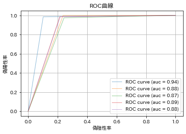

```python
import numpy as np  # numpy
import pandas as pd #pandas ライブリラの読み込み
from sklearn.datasets import load_breast_cancer # ヴィスコンシン州乳がんのデータセット
import matplotlib.pyplot as plt # プロットライブラリ
import japanize_matplotlib # プロット日本語対応ライブラリ
from sklearn.model_selection import train_test_split #データを訓練とテストに分割するためのライブラリ
from sklearn import svm # svmのライブラリ
from sklearn import metrics # ROC曲線計算
from sklearn.metrics import roc_curve, auc # auc-roc ライブラリ
from sklearn.model_selection import KFold # 交差検証のライブラリ

# ヴィスコンシン州乳がんのデータセットをdatasetに代入
dataset = load_breast_cancer()

X = pd.DataFrame(dataset.data, columns=dataset.feature_names)
y = pd.Series(dataset.target, name='type')

# svm関数をclf変数に代入
clf = svm.SVC()

# 交差検証
cv = KFold(n_splits=5, random_state=100, shuffle=True)

for train, test in cv.split(X, y):

    # .fit(モデル訓練用説明変数（特徴量），　モデル訓練用目的変数)でモデル訓練する．
    clf.fit(X.iloc[train,], y.iloc[train,])

    # 訓練したモデルに　.predict(テスト用説明変数(特徴量)) でテストデータの予測値をy_predに代入
    y_pred = clf.predict(X.iloc[test,])

    # FPR(偽陽性率), TPR(真陽性率), しきい値
    fpr, tpr, thresholds = roc_curve(y[test], y_pred)

    # AUC
    auc = metrics.auc(fpr, tpr)

    # ROC曲線をプロット
    plt.plot(fpr, tpr, alpha=0.5, lw=1,label='ROC curve (auc = %.2f)' %auc)
    plt.legend()
    plt.title('ROC曲線')
    plt.xlabel('偽陰性率')
    plt.ylabel('偽陽性率')
    plt.grid(True)
```

### **4.5 クロスバリデーション : 回帰**

```python
# 必要なライブラリのインポート
import pandas as pd # pandas
from sklearn.datasets import load_boston # ボストン宅地価格のデータセット
import matplotlib.pyplot as plt # プロットライブラリ
import japanize_matplotlib # プロット日本語対応ライブラリ
from sklearn.model_selection import train_test_split #データを訓練とテストに分割するためのライブラリ
from sklearn.ensemble import RandomForestRegressor # ランダムフォレストのライブラリ
from sklearn.model_selection import KFold # 交差検証のライブラリ

# 評価用ライブラリのインポート
from sklearn.metrics import mean_absolute_error # MAE
from scipy.stats import pearsonr #R
from sklearn.metrics import r2_score #R2
from sklearn.metrics import mean_squared_error # RMSE, MSE

# ボストン宅地価格のデータをdataset変数に代入
dataset = load_boston()

# Xという変数に説明変数（特徴量）をデータフレームの形で代入する．columnsで列名を設定する．
X = pd.DataFrame(dataset.data, columns=dataset.feature_names)

# yという変数に目的変数をデータフレームの形で代入する．columnsで列名を設定する．
# MEDV : 持家住宅の中央価格($1000単位)
y = pd.Series(dataset.target, name='MEDV')

# ランダムフォレスト関数をforest変数に代入
forest = RandomForestRegressor()

# それぞれのモデル関数とモデル名を格納する
models = [forest]
model_names = ['CV1','CV2','CV3','CV4','CV5']
eval_names = ['MAE','R','R2','MSE','RMSE']

cv = KFold(n_splits=5, random_state=100, shuffle=True)

# 評価値を格納する空リスト
eval = []

# クロスバリデーションの検証用データの格納する空リスト
valid_y = []
valid_y_pred = []

for train, test in cv.split(X, y):

    # モデル訓練
    forest.fit(X.iloc[train,], y.iloc[train,])
    # 訓練したモデルで予測値を計算
    y_pred = forest.predict(X.iloc[test,])

    # クロスバリデーションの検証用データの格納
    valid_y_pred.append(y_pred)
    valid_y.append(y[test])

    # MAE, R, R2, MSE, RMSEの計算
    mae = mean_absolute_error(y[test], y_pred)
    r = pearsonr(y[test], y_pred)
    r2 = r2_score(y[test], y_pred)
    mse = mean_squared_error(y[test], y_pred)
    rmse = np.sqrt(mean_squared_error(y[test], y_pred))
    # MAE, R, R2, MSE, RMSEの計算値をtmp_evalに格納
    tmp_eval = [mae, r, r2, mse, rmse]
    eval.append(tmp_eval)

# 評価値をデータフレーム形式で表示
pd.DataFrame(eval, columns=eval_names, index=model_names)
```

|  | MAE | R | R2 | MSE | RMSE |
| --- | --- | --- | --- | --- | --- |
| CV1 | 2.414186 | (0.9394394356340505, 2.634677694732374e-48) | 0.881193 | 11.476052 | 3.387632 |
| CV2 | 2.698030 | (0.8626512151469367, 4.566298296529893e-31) | 0.728933 | 23.403697 | 4.837737 |
| CV3 | 2.111495 | (0.9493872516939064, 1.3675273308098217e-51) | 0.897335 | 8.251448 | 2.872533 |
| CV4 | 1.811713 | (0.9577975143065782, 2.0801896910314295e-55) | 0.917340 | 5.813916 | 2.411206 |
| CV5 | 2.479693 | (0.9126879603374379, 2.926842173443565e-40) | 0.818222 | 15.785448 | 3.973091 |

```python
import itertools #ループ処理に関するライブラリ

# arrayリストを平坦化する
valid_y = tuple(itertools.chain.from_iterable(valid_y))
valid_y_pred = tuple(itertools.chain.from_iterable(valid_y_pred))

model_names = ['CV1','CV2','CV3','CV4','CV5', 'CV1-5']
eval_names = ['MAE','R','R2','MSE','RMSE']

# MAE, R, R2, MSE, RMSEの計算
mae = mean_absolute_error(valid_y, valid_y_pred)
r = pearsonr(valid_y, valid_y_pred)
r2 = r2_score(valid_y, valid_y_pred)
mse = mean_squared_error(valid_y, valid_y_pred)
rmse = np.sqrt(mean_squared_error(valid_y, valid_y_pred))
# MAE, R, R2, MSE, RMSEの計算値をtmp_evalに格納
tmp_eval = [mae, r, r2, mse, rmse]
eval.append(tmp_eval)

# 評価値をデータフレーム形式で表示
pd.DataFrame(eval, columns=eval_names, index=model_names)
```

|  | MAE | R | R2 | MSE | RMSE |
| --- | --- | --- | --- | --- | --- |
| CV1 | 2.414186 | (0.9394394356340505, 2.634677694732374e-48) | 0.881193 | 11.476052 | 3.387632 |
| CV2 | 2.698030 | (0.8626512151469367, 4.566298296529893e-31) | 0.728933 | 23.403697 | 4.837737 |
| CV3 | 2.111495 | (0.9493872516939064, 1.3675273308098217e-51) | 0.897335 | 8.251448 | 2.872533 |
| CV4 | 1.811713 | (0.9577975143065782, 2.0801896910314295e-55) | 0.917340 | 5.813916 | 2.411206 |
| CV5 | 2.479693 | (0.9126879603374379, 2.926842173443565e-40) | 0.818222 | 15.785448 | 3.973091 |
| CV1-5 | 2.303243 | (0.920236746920551, 1.762700660586819e-207) | 0.846680 | 12.943207 | 3.597667 |

#### **予測性能の可視化**

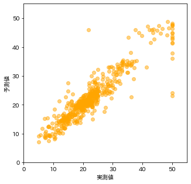

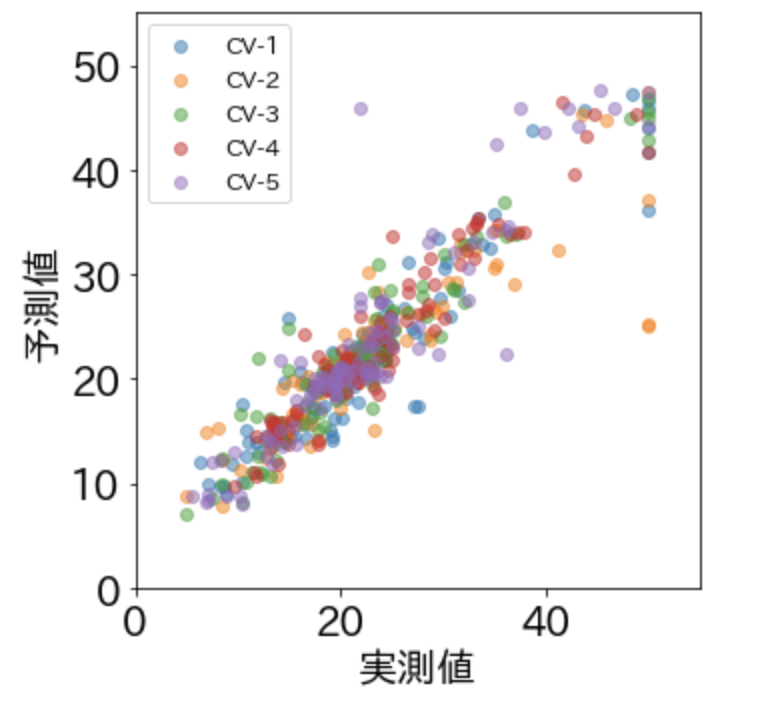

```python
plt.figure()
plt.figure(figsize=(5,5))
plt.xlim([0, 55.0])
plt.ylim([0, 55.0])
# クロスバリデーションの検証用データ, valid_y, valid_y_pred
plt.scatter(valid_y, valid_y_pred, color='orange', alpha=0.5)
plt.xlabel('実測値')
plt.ylabel('予測値')
plt.show()

# 各CVを色分けした場合の例
from IPython.display import Image
Image('CV5.png')
```

## **5. 前処理**

### **5.1 One-Hotエンコーディング**

基本的に機械学習の説明変数に文字などは扱えない  
そのような変数を学習できるように，数値に置き換えるための手法

```python
import pandas as pd # pandasを読み込む

# データを作成する
data = {
        'id' : [1, 2, 3 , 4],
        'workclass' : ['Government Employee', 'Self Employed', 'Private Employee', 'Private Employee']
        }

# df変数にデータフレーム形式で代入
df = pd.DataFrame(data)
df
```

|  | id | workclass |
| --- | --- | --- |
| 0 | 1 | Government Employee |
| 1 | 2 | Self Employed |
| 2 | 3 | Private Employee |
| 3 | 4 | Private Employee |

このままのデータでは機械学習に使えない（文字データは扱えない）

#### **get_dummies**

One-Hotエンコーディングを行うためのメソッド

```python
pd.get_dummies(df)
```

|  | id | workclass_Government Employee | workclass_Private Employee | workclass_Self Employed |
| --- | --- | --- | --- | --- |
| 0 | 1 | 1 | 0 | 0 |
| 1 | 2 | 0 | 0 | 1 |
| 2 | 3 | 0 | 1 | 0 |
| 3 | 4 | 0 | 1 | 0 |

```python
import pandas as pd
data = {
    '名前' :['田中', '佐藤', '山田','山崎'],
    '役職' : ['営業部部長', '広報部課長', '技術顧問', '人事部部長'],
    '身長' : [193, 163, 173, 155],
    '体重' : [70, 59, 68, 60],
    '血液型' : ['A', 'O', 'AB', 'B'],
    '星座' : ['山羊座', '牡羊座', '乙女座', '獅子座']
        }
df = pd.DataFrame(data)
df
```

```python
pd.get_dummies(df)
```

dataの中身を書き換え，pd.get_dummies(df)を実行して，どのように変わるかどうか確認してみる

```python
import pandas as pd
data = {
    '名前' :['田中', '佐藤', '山田','山崎'],
    '役職' : ['営業部部長', '広報部課長', '技術顧問', '人事部部長'],
    '身長' : [193, 163, 173, 155],
    '体重' : [70, 59, 68, 60],
    '血液型' : ['A', 'O', 'AB', 'B'],
    '星座' : ['山羊座', '牡羊座', '乙女座', '獅子座']
        }
df = pd.DataFrame(data)
df
```

```python
pd.get_dummies(df)
```

### **5.2 欠損値の対応**

#### **サンプルデータの読み込み**

```python
import numpy as np
from numpy import nan as NA
import pandas as pd

df = pd.read_csv('sample.csv')
print(df)
```

```
   Data1  Data2  Data3  Data4  Data5
0    4.0    2.0    3.2    4.0    5.5
1    NaN    6.0    NaN    7.0    NaN
2    8.0    NaN   12.0    5.1    9.9
3    1.0    2.0   11.0    2.1    4.9
4    3.0    NaN   15.1    7.1    3.9
5    5.0    2.0    0.1    6.1    1.4
6    9.0    2.0    3.5    7.1    8.4
```

データに空欄がある場合，そこのデータは"NaN"となる

#### **欠損値があるかの確認**

```python
# True or False で 欠損値があるかないかを返す
# isnullメソッド
df.isnull()
```

.isnull()は欠損値（NaN）がのデータをTrueで返す

```python
#sumメソッドを使って欠損値の個数を列ごとに見られる
df.isnull().sum()
```

#### **欠損データの削除**

```python
#同様に、axis=1を設定すればNaNを含んでいる特徴量（列）を削除できる。
df.dropna(axis=1)
```

```python
#欠損値を含む列を削除する
print(df.dropna(axis='columns'))
```

```python
# すべてNaNである行を削除
# この場合は全行残る
print(df.dropna(how='all'))
```

```python
# データを作成する
data = {
        'id' : [np.nan, 2, 3 , 4],
        'workclass' : [np.nan, 'Self Employed', 'Private Employee', 'Private Employee'],
        'workclass2' : [np.nan, 'Self Employed', 'Private Employee', 'Self Employed']
        }
# データフレーム形式に変換しprint表示
print(pd.DataFrame(data))
# データフレーム形式に変換し，すべてNaNである行を削除
print(pd.DataFrame(data).dropna(how='all'))
```

```python
# NaNでない値が3つ未満の行を削除
print(df)
print(df.dropna(thresh=3))
```

```python
# 特定の列にNaNが含まれている行だけを削除
print(df)
print(df.dropna(subset=['Data2']))
```

```python
# 列Data2の欠損値を20で穴埋め
print(df)
df['Data2'].fillna(20)
```

```python
# 列Data2の欠損値をData2の平均値で穴埋め
print(df)
df['Data2'].fillna(df['Data2'].mean())
```

```python
# 列Data2の欠損値をData2の中央値で穴埋め
df['Data2'].fillna(df['Data2'].median())
```

```python
# 列Data2の欠損値をData2の最頻値で穴埋め
print(df)
df['Data2'].fillna(df['Data2'].mode()[0])
```

### **5.3 正規化と標準化**

```python
import pandas as pd
import numpy as np
from sklearn.datasets import load_iris
from sklearn.model_selection import train_test_split
import matplotlib.pyplot as plt
import japanize_matplotlib

#アイリスデータセットをロードし，dataset変数に代入する
dataset = load_iris()

# Xという変数に説明変数（特徴量）をデータフレームの形で代入する．columnsで列名を設定する
X = pd.DataFrame(dataset.data, columns=dataset.feature_names)
# yという変数に目的変数をデータフレームの形で代入する．columnsで列名を設定する
y = pd.Series(dataset.target, name='type')
```

#### **説明変数をプロットする**

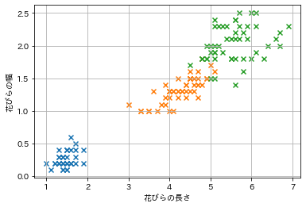

```python
#２つの説明変数を選択する
x1 = X.iloc[:,2]
x2 = X.iloc[:,3]
#２つの説明変数のみのデータを抽出
x = X.iloc[:,[2,3]]

# データを訓練とテストに分割
X_train, X_test, y_train, y_test = train_test_split(x, y, random_state=3)

#目的変数が0の説明変数x1とx2をプロットする
plt.scatter(x1[y==0],x2[y==0],marker='x')
#目的変数が1の説明変数x1とx2をプロットする
plt.scatter(x1[y==1],x2[y==1],marker='x')
#目的変数が2の説明変数x1とx2をプロットする
plt.scatter(x1[y==2],x2[y==2],marker='x')
plt.xlabel('花びらの長さ')
plt.ylabel('花びらの幅')
plt.grid()
plt.show()
```

```python
# 標準化
from sklearn.preprocessing import StandardScaler
stdsc = StandardScaler()

# 訓練用のデータを標準化
X_train_std = stdsc.fit_transform(X_train)
# 訓練用データを基準にテストデータも標準化
X_test_std = stdsc.transform(X_test)

# 平均と標準偏差を確認する
print('平均（訓練データ）：', X_train_std.mean())
print('標準偏差（訓練データ）：', X_train_std.std())
print('平均（テストデータ）：', X_test_std.mean())
print('標準偏差（テストデータ）：', X_test_std.std())
```

```
平均（訓練データ）： 2.73590673925485e-16
標準偏差（訓練データ）： 0.9999999999999998
平均（テストデータ）： -0.14066011772858067
標準偏差（テストデータ）： 1.0525549793820277
```

```python
# 正規化
from sklearn.preprocessing import MinMaxScaler
mmsc = MinMaxScaler()

# 訓練用のデータを正規化する
X_train_norm = mmsc.fit_transform(X_train)
# 訓練用データを基準にテストデータも正規化
X_test_norm = mmsc.transform(X_test)

# 正規化後の最大値と最小値を確認する
print('正規化した訓練データの最大値:', X_train_norm.max())
print('正規化した訓練データの最小値:',X_train_norm.min()) #
# test用はtrainを基準に標準化してるので、多少0,1からずれる
print('正規化したテストデータの最大値:',X_test_norm.max())
print('正規化したテストデータの最小値:',X_test_norm.min())
```

```
正規化した訓練データの最大値: 1.0
正規化した訓練データの最小値: 0.0
正規化したテストデータの最大値: 1.0350877192982457
正規化したテストデータの最小値: 0.03508771929824561
```

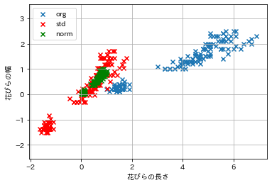

```python
plt.axis('equal')
plt.scatter(x.iloc[:,0],x.iloc[:,1], marker='x', label='org')
x_norm = mmsc.transform(x.iloc[:,[0,1]])
x_std = stdsc.transform(x.iloc[:,[0,1]])
plt.scatter(x_std[:,0],x_std[:,1], c='red',marker='x', label='std')
plt.scatter(x_norm[:,0],x_norm[:,1], c='green',marker='x', label='norm')
plt.legend()
plt.xlabel('花びらの長さ')
plt.ylabel('花びらの幅')
plt.grid()
plt.show()
```

青: 元データ，赤: 標準化，緑: 正規化  
青の元データは横軸（花びらの長さ）の方の分散（ばらつき）が大きい．緑のデータは正規化しているので[0, 1]内におさまっている

#### **ロジスティック回帰を用いて標準化の前後で比較**

```python
from sklearn.linear_model import LogisticRegression
from matplotlib.colors import ListedColormap

lr = LogisticRegression()
lr_std = LogisticRegression()

#元データのモデルの予測精度
lr.fit(X_train,y_train)
print('元データのスコア :',lr.score(X_test,y_test))

#標準化したデータのモデルの予測精度
lr_std.fit(X_train_std,y_train)
print('標準化したデータのスコア :',lr_std.score(X_test_std,y_test))
```

```
元データのスコア : 0.9736842105263158
標準化したデータのスコア : 0.9473684210526315
```

最近の機械学習アルゴリズムの性能やデータセットの種類によっては標準化を行わなくても良い学習モデルを作成できる

#### **ボストンの宅地価格のデータセットで比較**

```python
# 必要なライブラリのインポート
import pandas as pd # pandas
from sklearn.datasets import load_boston # ボストン宅地価格のデータセット
import matplotlib.pyplot as plt # プロットライブラリ
import japanize_matplotlib # プロット日本語対応ライブラリ
from sklearn.model_selection import train_test_split #データを訓練とテストに分割するためのライブラリ
from sklearn.ensemble import RandomForestRegressor # ランダムフォレストのライブラリ

dataset = load_boston()

# Xという変数に説明変数（特徴量）をデータフレームの形で代入する．columnsで列名を設定する．
X = pd.DataFrame(dataset.data, columns=dataset.feature_names)

# yという変数に目的変数をデータフレームの形で代入する．columnsで列名を設定する．
# MEDV : 持家住宅の中央価格($1000単位)
y = pd.Series(dataset.target, name='MEDV')

# データを訓練とテストに分割
X_train, X_test, y_train, y_test = train_test_split(X, y, random_state=1)
```

```python
# 標準化
from sklearn.preprocessing import StandardScaler
stdsc = StandardScaler()

# 訓練用のデータを標準化
X_train_std = stdsc.fit_transform(X_train)
# 訓練用データを基準にテストデータも標準化
X_test_std = stdsc.transform(X_test)

print(X_train_std.mean())
print(X_train_std.std())
print(X_test_std.mean())
print(X_test_std.std())
```

```
2.6441650213439084e-15
0.9999999999999998
-0.03219984186131262
0.9495391623590546
```

#### **Gradient Boostingを使って確認**

```python
# 必要なライブラリのインポート
from sklearn.ensemble import GradientBoostingRegressor

# モデル構築、パラメータはデフォルト
xgb = GradientBoostingRegressor()
xgb_std = GradientBoostingRegressor()

xgb.fit(X_train, y_train)
print('元データのスコア :',xgb.score(X_test,y_test))

xgb.fit(X_train_std,y_train)
print('標準化したデータのスコア :',xgb.score(X_test_std,y_test))
```

```
元データのスコア : 0.9245559844382623
標準化したデータのスコア : 0.9216134638882194
```

```python
# 正規化
from sklearn.preprocessing import MinMaxScaler
mmsc = MinMaxScaler()
# 訓練用のデータを正規化する
X_train_norm = mmsc.fit_transform(X_train)
# 訓練用データを基準にテストデータも正規化
X_test_norm = mmsc.transform(X_test)

print(X_train_norm.max())
print(X_train_norm.min())
print(X_test_norm.max())
print(X_test_norm.min())
```

```
1.0
0.0
1.0
-0.03297872340425531
```

```python
# 必要なライブラリのインポート
from sklearn.ensemble import GradientBoostingRegressor

# モデル構築、パラメータはデフォルト
xgb = GradientBoostingRegressor()
xgb_norm = GradientBoostingRegressor()

#元のデータのモデルの予測精度
xgb.fit(X_train, y_train)
print('元データのスコア :',xgb.score(X_test,y_test))

#正規化したデータのモデルの予測精度
xgb_norm.fit(X_train_norm,y_train)
print('正規化したデータのスコア :',xgb_norm.score(X_test_norm,y_test))
```

```
元データのスコア : 0.9170539724626562
正規化したデータのスコア : 0.9203336489238982
```

### **5.4 特徴量（説明変数）選択**

#### **分散を指標に特徴量（説明変数）を選択**

```python
import pandas as pd
from sklearn.model_selection import train_test_split
from sklearn.feature_selection import VarianceThreshold # 分散による特徴量選択ライブラリ

df = pd.read_csv('Tm_data.csv')
```

```python
# 特徴量と目的変数をXとyに代入
X = df.iloc[:,2:249] # 全行対象,3-249列目をXとする
y = df.iloc[:,1]  # 全行対象,2列名を目的変数にする

# データを訓練とテストに分割
X_train, X_test, y_train, y_test = train_test_split(X, y, random_state=1)
```

#### **分散が0のものを削除する**

```python
# 分散が0（すべて同じ値）のデータは削除します
sel = VarianceThreshold(threshold=0)
sel.fit(X_train)

# get_supportで保持するデータする数を表示する（True or Falseで表示）
print(sel.get_support())
# Trueの数を数える
print(sum(sel.get_support()))
```

```
[ True  True  True  True  True  True  True  True  True  True  True  True
  True  True  True  True  True  True  True  True  True  True  True  True
  True  True  True False False  True  True  True  True  True  True  True
  True  True  True False  True  True  True  True  True  True  True  True
  True  True  True  True  True  True  True  True  True  True  True  True
  True  True False False False False  True False  True  True  True  True
  True  True  True  True  True  True  True  True  True False  True False
  True  True  True  True False  True  True  True  True  True  True  True
  True  True  True  True False  True  True  True False False  True  True
 False  True  True  True  True  True  True  True False False False False
 False False False False False False False False False False False  True
 False False False False  True False False False False  True  True  True
  True  True  True  True  True  True  True  True  True  True  True  True
  True  True  True  True  True  True  True  True  True  True  True  True
  True  True  True  True  True  True  True  True  True  True  True  True
  True  True  True  True  True  True  True  True  True  True  True  True
  True  True  True  True  True  True  True  True  True  True  True  True
  True  True  True  True  True  True  True  True  True  True  True  True
 False False False False False False False False False False False False
 False False False False False False False False False False False False
 False False False False False  True  True]
180
```

```python
# Trueの列を選択し直す
X_train_filter = X_train.loc[:, sel.get_support()]
X_test_filter = X_test.loc[:, sel.get_support()]
```

```python
# 必要なライブラリのインポート
from sklearn.ensemble import RandomForestRegressor # ランダムフォレストのライブラリ

# モデル構築、パラメータはデフォルト
rf = RandomForestRegressor()
rf_filter = RandomForestRegressor()

#元のデータをモデルの予測精度
rf.fit(X_train, y_train)
print('元データのスコア :',rf.score(X_test,y_test))

#データをフィルターしたモデルの予測精度
rf_filter.fit(X_train_filter,y_train)
print('フィルター後のスコア :',rf_filter.score(X_test_filter,y_test))
```

```
元データのスコア : 0.823238997775293
フィルター後のスコア : 0.8206781983574001
```

#### **分散が0に近いのものを削除する**

```python
# 分散が0.01以下のデータは削除します
sel = VarianceThreshold(threshold=0.01)
sel.fit(X_train)

# get_supportで保持するデータする数を表示する（True or Falseで表示）
print(sel.get_support())
# Trueの数を数える
print(sum(sel.get_support()))
```

```
[ True  True  True  True  True  True  True  True  True  True  True  True
  True  True  True  True  True  True  True  True  True  True False False
  True  True False False False  True  True  True  True  True  True  True
  True  True  True False  True  True False  True  True  True  True  True
  True  True  True  True  True  True  True  True False  True False  True
  True  True False False False False False False  True  True  True False
  True  True  True False  True  True  True  True  True False  True False
 False  True  True  True False  True  True  True  True  True False  True
  True  True  True  True False False False  True False False False False
 False  True  True  True  True False  True  True False False False False
 False False False False False False False False False False False  True
 False False False False  True False False False False  True  True  True
  True  True  True  True  True  True  True  True  True  True  True  True
  True  True  True  True  True  True  True  True  True  True  True  True
  True  True  True  True  True  True  True  True  True  True False False
 False  True  True False False False False  True  True  True  True  True
  True  True  True  True  True  True  True  True  True  True  True  True
  True  True  True  True  True False False False  True  True  True  True
 False False False False False False False False False False False False
 False False False False False False False False False False False False
 False False False False False  True  True]
154
```

```python
# Trueの列を選択し直す
X_train_filter = X_train.loc[:, sel.get_support()]
X_test_filter = X_test.loc[:, sel.get_support()]
```

```python
# 必要なライブラリのインポート
from sklearn.ensemble import RandomForestRegressor # ランダムフォレストのライブラリ

# モデル構築、パラメータはデフォルト
rf = RandomForestRegressor()
rf_filter = RandomForestRegressor()

#元のデータをモデルの予測精度
rf.fit(X_train, y_train)
print('元データのスコア :',rf.score(X_test,y_test))

#データをフィルターしたモデルの予測精度
rf_filter.fit(X_train_filter,y_train)
print('フィルター後のスコア :',rf_filter.score(X_test_filter,y_test))
```

```
元データのスコア : 0.8224228437728064
フィルター後のスコア : 0.8233417447489197
```

## **6. パラメーターチューニング**

### **6.1 機械学習手法のパラメータを調整する**

#### **Elastic Net ：λを調整する（scikit-learn上ではα表記）**

```python
import pandas as pd # pandas
from sklearn.datasets import load_iris
from sklearn.linear_model import ElasticNet
from sklearn.model_selection import train_test_split
import matplotlib.pyplot as plt # プロットライブラリ
import japanize_matplotlib # プロット日本語対応ライブラリ

dataset = load_iris()

# Xという変数に説明変数（特徴量）をデータフレームの形で代入する．columnsで列名を設定する．
X = pd.DataFrame(dataset.data, columns=dataset.feature_names)

# yという変数に目的変数をデータフレームの形で代入する．columnsで列名を設定する．
y = pd.Series(dataset.target, name='type')

# データを訓練とテストに分割
X_train, X_test, y_train, y_test = train_test_split(X, y, random_state=1)
```

```python
#ElasticNet
En = ElasticNet(alpha = 1.0, l1_ratio=0.5, max_iter=100)
```

L1正則化 : パラメータ削減

L2正則化 : 学習の精度を上げる

```python
# パラメータ
alpha = 0.1
ratio = 0.1
#ElasticNet
En = ElasticNet(alpha = alpha, l1_ratio=ratio, max_iter=100)

# .fit(モデル訓練用説明変数（特徴量），　モデル訓練用目的変数)でモデル訓練する．
En.fit(X_train, y_train)

# 説明変数（特徴量）をfeat_namesに代入
feat_names = ['がくの長さ(Sepal Length)', 'がくの幅 (Sepal Width)', '花びらの長さ (Petal Length)', '花びらの幅 (Petal Width)']

# 訓練したモデルの回帰係数 ridge.coef_ を pandas Series型としてcoefに代入．feat_namesを使ってそれぞれにindex名を付ける．
coef = pd.Series(En.coef_, index = feat_names)

# 回帰係数が大きい順にソート
imp_coef = coef.sort_values()

# 水平棒グラフ
imp_coef.plot(kind = "barh")

# タイトルを付ける
plt.title("Ridge回帰係数");

# 精度
En.score(X_test, y_test)
```

#### **サポートベクターマシーン**

```python
import pandas as pd
from sklearn.datasets import load_iris
from sklearn.svm import SVC

dataset = load_iris()

# Xという変数に説明変数（特徴量）をデータフレームの形で代入する．columnsで列名を設定する．
X = pd.DataFrame(dataset.data, columns=dataset.feature_names)

# yという変数に目的変数をデータフレームの形で代入する．columnsで列名を設定する．
y = pd.Series(dataset.target, name='type')

# データを訓練とテストに分割
X_train, X_test, y_train, y_test = train_test_split(X, y, random_state=1)
```

svm.SVC(C=C, gamma=gamma)

コストパラメータ: C  
分類の誤りをどの程度許容するか

RBFカーネルのパラメータ: γ（gamma）  
γの値が小さいほど単純な決定境界  
大きいほど複雑な決定境界となる

```python
# パラメータ
C = 10
gamma = 10

#SVM
SVM = SVC(C=C, gamma=gamma)

# .fit(モデル訓練用説明変数（特徴量），　モデル訓練用目的変数)でモデル訓練する．
SVM.fit(X_train, y_train)

# 精度
SVM.score(X_test, y_test)
```

```
0.9473684210526315
```

### **6.2 ハイパーパラメータチューニング**

#### **グリッドサーチ**

```python
from sklearn import datasets, svm, model_selection
from sklearn.model_selection import train_test_split, GridSearchCV # GridSearchCVはグリッドサーチ用のライブラリ
from sklearn.svm import SVC

#アイリスデータセットをロードし，dataset変数に代入する
dataset = load_iris()

# Xという変数に説明変数（特徴量）をデータフレームの形で代入する．columnsで列名を設定する．
X = pd.DataFrame(dataset.data, columns=dataset.feature_names)

# yという変数に目的変数をデータフレームの形で代入する．columnsで列名を設定する．
y = pd.Series(dataset.target, name='type')

# サーチするパラメータリスト(Cとgamma)
pbounds = {
    'C': (0.1, 1.0, 10, 100, 200, 400, 500, 1000),
    'gamma': (0.1, 1.0, 10, 100, 200, 400, 500, 1000)
}

X_train, X_test, y_train, y_test = train_test_split(X, y, random_state=10)

# pboundsのリストの組み合わせでグリッドサーチをする
grid_search = GridSearchCV(svm.SVC(), pbounds, cv=5).fit(X_train, y_train)

print(grid_search.score(X_test, y_test))
print("best_params:{}".format(grid_search.best_params_))
```

```
0.9736842105263158
best_params:{'C': 10, 'gamma': 0.1}
```

#### **ベイズ最適化**

```python
from bayes_opt import BayesianOptimization #ベイズ最適ライブラリ

# 1変数関数の定義
def f(x):
    return -(x**5 - 20 * x**3 + 10 * x) + 300

# 最適化するパラメータの下限・上限 (xのみ)
pbounds = {
    'x': (-5.0, 5.0)
}

# 関数と最適化するパラメータを渡す
# fはモデルを入力する（ここでは上で定義した関数）
# pboundsは探索するパラメータの範囲
optimizer = BayesianOptimization(f=f, pbounds=pbounds)

# 最適化
# 計算回数：iter = init_points + n_iter
optimizer.maximize(init_points=3, n_iter=20)
```

```
|   iter    |  target   |     x     |
-------------------------------------
|  1        |  557.4    |  3.848    |
|  2        |  287.3    | -1.076    |
|  3        |  374.6    | -4.508    |
|  4        | -375.0    |  5.0      |
|  5        |  570.4    |  3.782    |
|  6        |  513.8    |  2.643    |
|  7        |  340.9    |  1.459    |
|  8        |  28.06    | -3.041    |
|  9        |  298.0    |  0.221    |
|  10       |  584.9    |  3.165    |
|  11       |  975.0    | -5.0      |
|  12       |  197.9    | -1.96     |
|  13       |  830.9    | -4.907    |
|  14       |  420.1    |  2.079    |
|  15       |  420.1    |  2.079    |
|  16       |  420.1    |  2.079    |
|  17       |  420.1    |  2.079    |
|  18       |  420.1    |  2.079    |
|  19       |  420.1    |  2.079    |
|  20       |  420.1    |  2.079    |
|  21       |  420.1    |  2.079    |
|  22       |  420.1    |  2.079    |
|  23       |  420.1    |  2.079    |
=====================================
```

```python
from sklearn import model_selection
from sklearn.svm import SVC

#アイリスデータセットをロードし，dataset変数に代入する
dataset = load_iris()

# Xという変数に説明変数（特徴量）をデータフレームの形で代入する．columnsで列名を設定する．
X = pd.DataFrame(dataset.data, columns=dataset.feature_names)

# yという変数に目的変数をデータフレームの形で代入する．columnsで列名を設定する．
y = pd.Series(dataset.target, name='type')

def validate(C, gamma):
    # 与えられたパラメータでSVMのモデルを初期化
    model = SVC(C=C, gamma=gamma)

    # 5-Foldで交差検証
    result = model_selection.cross_validate(model, X, y, cv=5)

    # 精度を返す
    return np.mean(result['test_score'])
```

```python
# 最適化するパラメータの下限・上限 (Cとgamma)
pbounds = {
    'C': (0.001, 1000),
    'gamma': (0.001, 1000)
}

# 関数と最適化するパラメータを渡す
optimizer = BayesianOptimization(f=validate, pbounds=pbounds)

# 最適化 iter = init_points + n_iter
optimizer.maximize(init_points=5, n_iter=20, acq='ucb')
```

```
|   iter    |  target   |     C     |   gamma   |
-------------------------------------------------
|  1        |  0.4      |  677.2    |  933.1    |
|  2        |  0.4      |  895.5    |  787.6    |
|  3        |  0.7933   |  245.4    |  35.36    |
|  4        |  0.4      |  998.2    |  601.4    |
|  5        |  0.4      |  509.9    |  790.3    |
|  6        |  0.88     |  228.9    |  20.57    |
|  7        |  0.9133   |  154.8    |  16.32    |
|  8        |  0.8067   |  247.4    |  32.27    |
|  9        |  0.92     |  1.874    |  11.75    |
|  10       |  0.98     |  555.4    |  0.001    |
|  11       |  0.98     |  741.6    |  0.001    |
|  12       |  0.5667   |  679.1    |  185.3    |
|  13       |  0.98     |  949.6    |  0.001    |
|  14       |  0.4      |  0.001    |  1e+03    |
|  15       |  0.5667   |  1e+03    |  172.5    |
|  16       |  0.4      |  0.001    |  468.7    |
|  17       |  0.9533   |  838.5    |  2.055    |
|  18       |  0.9867   |  437.6    |  0.001    |
|  19       |  0.4      |  1e+03    |  1e+03    |
|  20       |  0.98     |  1e+03    |  0.001    |
|  21       |  0.9867   |  650.4    |  0.001    |
|  22       |  0.9867   |  489.5    |  0.001    |
|  23       |  0.98     |  74.7     |  0.001    |
|  24       |  0.9867   |  693.9    |  0.001    |
|  25       |  0.9333   |  165.2    |  1.083    |
=================================================
```